# Predict Bike Sharing Demand with AutoGluon Template

## Project: Predict Bike Sharing Demand with AutoGluon

This notebook is a template with each step that you need to complete for the project.

Please fill in your code where there are explicit `?` markers in the notebook. You are welcome to add more cells and code as you see fit.

Once you have completed all the code implementations, please export your notebook as a HTML file so the reviews can view your code. Make sure you have all outputs correctly outputted.

`File-> Export Notebook As... -> Export Notebook as HTML`

There is a writeup to complete as well after all code implememtation is done. Please answer all questions and attach the necessary tables and charts. You can complete the writeup in either markdown or PDF.

Completing the code template and writeup template will cover all of the rubric points for this project.

The rubric contains "Stand Out Suggestions" for enhancing the project beyond the minimum requirements. The stand out suggestions are optional. If you decide to pursue the "stand out suggestions", you can include the code in this notebook and also discuss the results in the writeup file.

## Step 1: Create an account with Kaggle

### Create Kaggle Account and download API key

Below is example of steps to get the API username and key. Each student will have their own username and key.

1. Open account settings.

2. Scroll down to API and click Create New API Token.

3. Open up `kaggle.json` and use the username and key.


## Step 2: Download the Kaggle dataset using the kaggle python library

### Open up Sagemaker Studio and use starter template

1. Notebook should be using a `ml.t3.medium` instance (2 vCPU + 4 GiB)
2. Notebook should be using kernal: `Python 3 (MXNet 1.8 Python 3.7 CPU Optimized)`

### Install packages

```python
!pip install -U pip
!pip install -U setuptools wheel
!pip install -U "mxnet<2.0.0" bokeh==2.0.1
!pip install autogluon --no-cache-dir
# Without --no-cache-dir, smaller aws instances may have trouble installing
```

[output not shown]

[output cut: 31 more lines]

[output not shown]

### Setup Kaggle API Key

```python
# create the .kaggle directory and an empty kaggle.json file
!mkdir -p /root/.kaggle
!touch /root/.kaggle/kaggle.json
!chmod 600 /root/.kaggle/kaggle.json
```

```python
# Fill in your user name and key from creating the kaggle account and API token file
import json
kaggle_username = "ashutoshapatwardhan"
kaggle_key = "bde3c52416000050ae294b96fd8922a3"

# Save API token the kaggle.json file
with open("/root/.kaggle/kaggle.json", "w") as f:
    f.write(json.dumps({"username": kaggle_username, "key": kaggle_key}))
```

### Download and explore dataset

### Go to the bike sharing demand competition and agree to the terms

```python
# Download the dataset, it will be in a .zip file so you'll need to unzip it as well.
!kaggle competitions download -c bike-sharing-demand
# If you already downloaded it you can use the -o command to overwrite the file
!unzip -o bike-sharing-demand.zip
```

```
bike-sharing-demand.zip: Skipping, found more recently modified local copy (use --force to force download)
Archive:  bike-sharing-demand.zip
  inflating: sampleSubmission.csv
  inflating: test.csv
  inflating: train.csv
```

```python
import pandas as pd
from autogluon.tabular import TabularPredictor
import numpy as np
import matplotlib.pyplot as plt
import warnings
```

```python
# Create the train dataset in pandas by reading the csv
# Set the parsing of the datetime column so you can use some of the `dt` features in pandas later
train = pd.read_csv('train.csv', parse_dates=['datetime'])
train.head()
```

|  | datetime | season | holiday | workingday | weather | temp | atemp | humidity | windspeed | casual | registered | count |
| --- | --- | --- | --- | --- | --- | --- | --- | --- | --- | --- | --- | --- |
| 0 | 2011-01-01 00:00:00 | 1 | 0 | 0 | 1 | 9.84 | 14.395 | 81 | 0.0 | 3 | 13 | 16 |
| 1 | 2011-01-01 01:00:00 | 1 | 0 | 0 | 1 | 9.02 | 13.635 | 80 | 0.0 | 8 | 32 | 40 |
| 2 | 2011-01-01 02:00:00 | 1 | 0 | 0 | 1 | 9.02 | 13.635 | 80 | 0.0 | 5 | 27 | 32 |
| 3 | 2011-01-01 03:00:00 | 1 | 0 | 0 | 1 | 9.84 | 14.395 | 75 | 0.0 | 3 | 10 | 13 |
| 4 | 2011-01-01 04:00:00 | 1 | 0 | 0 | 1 | 9.84 | 14.395 | 75 | 0.0 | 0 | 1 | 1 |

```python
# Simple output of the train dataset to view some of the min/max/varition of the dataset features.
train.describe()
```

|  | season | holiday | workingday | weather | temp | atemp | humidity | windspeed | casual | registered | count |
| --- | --- | --- | --- | --- | --- | --- | --- | --- | --- | --- | --- |
| count | 10886.000000 | 10886.000000 | 10886.000000 | 10886.000000 | 10886.00000 | 10886.000000 | 10886.000000 | 10886.000000 | 10886.000000 | 10886.000000 | 10886.000000 |
| mean | 2.506614 | 0.028569 | 0.680875 | 1.418427 | 20.23086 | 23.655084 | 61.886460 | 12.799395 | 36.021955 | 155.552177 | 191.574132 |
| std | 1.116174 | 0.166599 | 0.466159 | 0.633839 | 7.79159 | 8.474601 | 19.245033 | 8.164537 | 49.960477 | 151.039033 | 181.144454 |
| min | 1.000000 | 0.000000 | 0.000000 | 1.000000 | 0.82000 | 0.760000 | 0.000000 | 0.000000 | 0.000000 | 0.000000 | 1.000000 |
| 25% | 2.000000 | 0.000000 | 0.000000 | 1.000000 | 13.94000 | 16.665000 | 47.000000 | 7.001500 | 4.000000 | 36.000000 | 42.000000 |
| 50% | 3.000000 | 0.000000 | 1.000000 | 1.000000 | 20.50000 | 24.240000 | 62.000000 | 12.998000 | 17.000000 | 118.000000 | 145.000000 |
| 75% | 4.000000 | 0.000000 | 1.000000 | 2.000000 | 26.24000 | 31.060000 | 77.000000 | 16.997900 | 49.000000 | 222.000000 | 284.000000 |
| max | 4.000000 | 1.000000 | 1.000000 | 4.000000 | 41.00000 | 45.455000 | 100.000000 | 56.996900 | 367.000000 | 886.000000 | 977.000000 |

```python
# Create the test pandas dataframe in pandas by reading the csv, remember to parse the datetime!
test = pd.read_csv('test.csv', parse_dates=['datetime'])
test.head()
```

|  | datetime | season | holiday | workingday | weather | temp | atemp | humidity | windspeed |
| --- | --- | --- | --- | --- | --- | --- | --- | --- | --- |
| 0 | 2011-01-20 00:00:00 | 1 | 0 | 1 | 1 | 10.66 | 11.365 | 56 | 26.0027 |
| 1 | 2011-01-20 01:00:00 | 1 | 0 | 1 | 1 | 10.66 | 13.635 | 56 | 0.0000 |
| 2 | 2011-01-20 02:00:00 | 1 | 0 | 1 | 1 | 10.66 | 13.635 | 56 | 0.0000 |
| 3 | 2011-01-20 03:00:00 | 1 | 0 | 1 | 1 | 10.66 | 12.880 | 56 | 11.0014 |
| 4 | 2011-01-20 04:00:00 | 1 | 0 | 1 | 1 | 10.66 | 12.880 | 56 | 11.0014 |

```python
# Same thing as train and test dataset
submission = pd.read_csv('sampleSubmission.csv', parse_dates=['datetime'])
submission.head()
```

|  | datetime | count |
| --- | --- | --- |
| 0 | 2011-01-20 00:00:00 | 0 |
| 1 | 2011-01-20 01:00:00 | 0 |
| 2 | 2011-01-20 02:00:00 | 0 |
| 3 | 2011-01-20 03:00:00 | 0 |
| 4 | 2011-01-20 04:00:00 | 0 |

Check if `test` and `submission` data frames have the same `datetime` column in the same order.

```python
sum(test['datetime'] != submission['datetime'])
```

```
0
```

Yes, `test` and `submission` have identical `datetime` columns.

```python
# check that casual and registered columns were deleted
train.head()
```

|  | datetime | season | holiday | workingday | weather | temp | atemp | humidity | windspeed | casual | registered | count |
| --- | --- | --- | --- | --- | --- | --- | --- | --- | --- | --- | --- | --- |
| 0 | 2011-01-01 00:00:00 | 1 | 0 | 0 | 1 | 9.84 | 14.395 | 81 | 0.0 | 3 | 13 | 16 |
| 1 | 2011-01-01 01:00:00 | 1 | 0 | 0 | 1 | 9.02 | 13.635 | 80 | 0.0 | 8 | 32 | 40 |
| 2 | 2011-01-01 02:00:00 | 1 | 0 | 0 | 1 | 9.02 | 13.635 | 80 | 0.0 | 5 | 27 | 32 |
| 3 | 2011-01-01 03:00:00 | 1 | 0 | 0 | 1 | 9.84 | 14.395 | 75 | 0.0 | 3 | 10 | 13 |
| 4 | 2011-01-01 04:00:00 | 1 | 0 | 0 | 1 | 9.84 | 14.395 | 75 | 0.0 | 0 | 1 | 1 |

```python
print('there are {} rows in the training data set.'.format(train.shape[0]))
```

```
there are 10886 rows in the training data set.
```

```python
train.info()
```

```
<class 'pandas.core.frame.DataFrame'>
RangeIndex: 10886 entries, 0 to 10885
Data columns (total 12 columns):
 #   Column      Non-Null Count  Dtype
---  ------      --------------  -----
 0   datetime    10886 non-null  datetime64[ns]
 1   season      10886 non-null  int64
 2   holiday     10886 non-null  int64
 3   workingday  10886 non-null  int64
 4   weather     10886 non-null  int64
 5   temp        10886 non-null  float64
 6   atemp       10886 non-null  float64
 7   humidity    10886 non-null  int64
 8   windspeed   10886 non-null  float64
 9   casual      10886 non-null  int64
 10  registered  10886 non-null  int64
 11  count       10886 non-null  int64
dtypes: datetime64[ns](1), float64(3), int64(8)
memory usage: 1020.7 KB
```

The number of non-null entries in each column of the training data set equals the number of rows in the training data set. So, there are no missing entries in the training data set.

```python
print('there are {} rows in the test data set.'.format(test.shape[0]))
```

```
there are 6493 rows in the test data set.
```

```python
test.info()
```

```
<class 'pandas.core.frame.DataFrame'>
RangeIndex: 6493 entries, 0 to 6492
Data columns (total 9 columns):
 #   Column      Non-Null Count  Dtype
---  ------      --------------  -----
 0   datetime    6493 non-null   datetime64[ns]
 1   season      6493 non-null   int64
 2   holiday     6493 non-null   int64
 3   workingday  6493 non-null   int64
 4   weather     6493 non-null   int64
 5   temp        6493 non-null   float64
 6   atemp       6493 non-null   float64
 7   humidity    6493 non-null   int64
 8   windspeed   6493 non-null   float64
dtypes: datetime64[ns](1), float64(3), int64(5)
memory usage: 456.7 KB
```

Similarly, there are no missing entries in the test data set.

## Step 3: Train a model using AutoGluon’s Tabular Prediction

Requirements:

- We are prediting `count`, so it is the label we are setting.
- Ignore `casual` and `registered` columns as they are also not present in the test dataset.
- Use the `root_mean_squared_error` as the metric to use for evaluation.
- Set a time limit of 10 minutes (600 seconds).
- Use the preset `best_quality` to focus on creating the best model.

```python
ignored_columns = ['registered', 'casual']

learner_kwargs = {
    'ignored_columns': ignored_columns
}
```

```python
time_limit = 600
```

```python
# autogluon generates a LOT of warnings about future deprecation. suppress these warnings.
warnings.filterwarnings('ignore', '.*deprecated*.')
```

```python
count = 'count'
```

```python
predictor = TabularPredictor(label=count,
                             learner_kwargs=learner_kwargs,
                             eval_metric='root_mean_squared_error').fit(train,
                                                                        presets='best_quality',
                                                                        time_limit=time_limit)
```

```
No path specified. Models will be saved in: "AutogluonModels/ag-20211115_013122/"
Presets specified: ['best_quality']
Beginning AutoGluon training ... Time limit = 600s
AutoGluon will save models to "AutogluonModels/ag-20211115_013122/"
AutoGluon Version:  0.3.1
Train Data Rows:    10886
Train Data Columns: 11
Preprocessing data ...
AutoGluon infers your prediction problem is: 'regression' (because dtype of label-column == int and many unique label-values observed).
	Label info (max, min, mean, stddev): (977, 1, 191.57413, 181.14445)
	If 'regression' is not the correct problem_type, please manually specify the problem_type argument in fit() (You may specify problem_type as one of: ['binary', 'multiclass', 'regression'])
Using Feature Generators to preprocess the data ...
Dropping user-specified ignored columns: ['registered', 'casual']
Fitting AutoMLPipelineFeatureGenerator...
	Available Memory:                    3117.63 MB
	Train Data (Original)  Memory Usage: 0.78 MB (0.0% of available memory)
	Inferring data type of each feature based on column values. Set feature_metadata_in to manually specify special dtypes of the features.
	Stage 1 Generators:
		Fitting AsTypeFeatureGenerator...
			Note: Converting 2 features to boolean dtype as they only contain 2 unique values.
	Stage 2 Generators:
		Fitting FillNaFeatureGenerator...
	Stage 3 Generators:
		Fitting IdentityFeatureGenerator...
		Fitting DatetimeFeatureGenerator...
	Stage 4 Generators:
		Fitting DropUniqueFeatureGenerator...
	Types of features in original data (raw dtype, special dtypes):
		('datetime', []) : 1 | ['datetime']
		('float', [])    : 3 | ['temp', 'atemp', 'windspeed']
		('int', [])      : 5 | ['season', 'holiday', 'workingday', 'weather', 'humidity']
	Types of features in processed data (raw dtype, special dtypes):
		('float', [])                : 3 | ['temp', 'atemp', 'windspeed']
		('int', [])                  : 3 | ['season', 'weather', 'humidity']
		('int', ['bool'])            : 2 | ['holiday', 'workingday']
		('int', ['datetime_as_int']) : 1 | ['datetime']
	0.2s = Fit runtime
	9 features in original data used to generate 9 features in processed data.
	Train Data (Processed) Memory Usage: 0.63 MB (0.0% of available memory)
Data preprocessing and feature engineering runtime = 0.21s ...
AutoGluon will gauge predictive performance using evaluation metric: 'root_mean_squared_error'
	To change this, specify the eval_metric argument of fit()
AutoGluon will fit 2 stack levels (L1 to L2) ...
Fitting 11 L1 models ...
Fitting model: KNeighborsUnif_BAG_L1 ... Training model for up to 399.76s of the 599.78s of remaining time.
	-160.4131	 = Validation score   (root_mean_squared_error)
	0.02s	 = Training   runtime
	0.1s	 = Validation runtime
Fitting model: KNeighborsDist_BAG_L1 ... Training model for up to 399.37s of the 599.4s of remaining time.
	-169.5521	 = Validation score   (root_mean_squared_error)
	0.02s	 = Training   runtime
	0.1s	 = Validation runtime
Fitting model: LightGBMXT_BAG_L1 ... Training model for up to 398.99s of the 599.02s of remaining time.
```

[output not shown]

```
	-134.0883	 = Validation score   (root_mean_squared_error)
	45.08s	 = Training   runtime
	2.2s	 = Validation runtime
Fitting model: LightGBM_BAG_L1 ... Training model for up to 345.82s of the 545.85s of remaining time.
```

```
[1000]	train_set's rmse: 96.0217	valid_set's rmse: 123.249
[1000]	train_set's rmse: 94.7479	valid_set's rmse: 135.635
[1000]	train_set's rmse: 95.3055	valid_set's rmse: 132.087
[1000]	train_set's rmse: 95.1635	valid_set's rmse: 131.521
```

```
	-132.2864	 = Validation score   (root_mean_squared_error)
	12.55s	 = Training   runtime
	0.45s	 = Validation runtime
Fitting model: RandomForestMSE_BAG_L1 ... Training model for up to 330.94s of the 530.97s of remaining time.
	-118.4567	 = Validation score   (root_mean_squared_error)
	6.98s	 = Training   runtime
	0.38s	 = Validation runtime
Fitting model: CatBoost_BAG_L1 ... Training model for up to 321.17s of the 521.2s of remaining time.
	-132.3497	 = Validation score   (root_mean_squared_error)
	54.29s	 = Training   runtime
	0.05s	 = Validation runtime
Fitting model: ExtraTreesMSE_BAG_L1 ... Training model for up to 266.08s of the 466.1s of remaining time.
	-128.7334	 = Validation score   (root_mean_squared_error)
	3.03s	 = Training   runtime
	0.38s	 = Validation runtime
Fitting model: NeuralNetFastAI_BAG_L1 ... Training model for up to 260.22s of the 460.25s of remaining time.
	-138.0151	 = Validation score   (root_mean_squared_error)
	104.35s	 = Training   runtime
	0.29s	 = Validation runtime
Fitting model: XGBoost_BAG_L1 ... Training model for up to 154.85s of the 354.88s of remaining time.
	-132.3085	 = Validation score   (root_mean_squared_error)
	14.46s	 = Training   runtime
	0.14s	 = Validation runtime
Fitting model: NeuralNetMXNet_BAG_L1 ... Training model for up to 138.2s of the 338.23s of remaining time.
	Ran out of time, stopping training early. (Stopping on epoch 11)
	Ran out of time, stopping training early. (Stopping on epoch 14)
	Ran out of time, stopping training early. (Stopping on epoch 15)
	Ran out of time, stopping training early. (Stopping on epoch 15)
	Ran out of time, stopping training early. (Stopping on epoch 16)
	Ran out of time, stopping training early. (Stopping on epoch 16)
	Ran out of time, stopping training early. (Stopping on epoch 17)
	Ran out of time, stopping training early. (Stopping on epoch 19)
	Ran out of time, stopping training early. (Stopping on epoch 21)
	Ran out of time, stopping training early. (Stopping on epoch 26)
	-143.2185	 = Validation score   (root_mean_squared_error)
	131.26s	 = Training   runtime
	1.46s	 = Validation runtime
Fitting model: LightGBMLarge_BAG_L1 ... Training model for up to 4.84s of the 204.86s of remaining time.
	Ran out of time, early stopping on iteration 77. Best iteration is:
	[77]	train_set's rmse: 116.334	valid_set's rmse: 132.733
```

[output cut: 33 more lines]

```
	Ran out of time, stopping training early. (Stopping on epoch 29)
	-115.4612	 = Validation score   (root_mean_squared_error)
	100.38s	 = Training   runtime
	0.32s	 = Validation runtime
Fitting model: XGBoost_BAG_L2 ... Training model for up to 12.19s of the 12.16s of remaining time.
	-117.1322	 = Validation score   (root_mean_squared_error)
	11.17s	 = Training   runtime
	0.07s	 = Validation runtime
Completed 1/20 k-fold bagging repeats ...
Fitting model: WeightedEnsemble_L3 ... Training model for up to 360.0s of the -0.12s of remaining time.
	-114.7421	 = Validation score   (root_mean_squared_error)
	0.36s	 = Training   runtime
	0.0s	 = Validation runtime
AutoGluon training complete, total runtime = 600.74s ...
TabularPredictor saved. To load, use: predictor = TabularPredictor.load("AutogluonModels/ag-20211115_013122/")
```

### Visually check how well the model fits the training data

```python
def visual_check(df, target, predictor, title=None):
    '''
    plot actual target values (x-axis) against predicted target values (y-axis)
    df: data frame
    target: (str) column containing the target variable
    predictor: fitted model
    '''
    plt.scatter(x=df[target], y=predictor.predict(df))
    plt.xlabel('actual target')
    plt.ylabel('predicted target')
    plt.title(title);
```

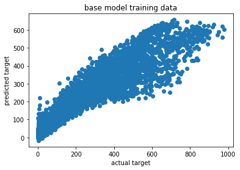

```python
visual_check(train, count, predictor, 'base model training data')
```

**Remark**: the above scatter plot is not as tightly grouped as hoped. It is also interesting that the model is unable to predict the higher instances of `count`. Perhaps feature engineering and hyperparameter tuning will improve it.

### Review AutoGluon's training run with ranking of models that did the best.

```python
predictor.fit_summary()
```

```
*** Summary of fit() ***
Estimated performance of each model:
                     model   score_val  pred_time_val    fit_time  pred_time_val_marginal  fit_time_marginal  stack_level  can_infer  fit_order
0      WeightedEnsemble_L3 -114.742090       6.690837  508.148627                0.000691           0.360293            3       True         19
1   NeuralNetFastAI_BAG_L2 -115.461202       5.859614  472.425136                0.315222         100.379442            2       True         17
2        LightGBMXT_BAG_L2 -116.128477       5.766613  382.268045                0.222221          10.222351            2       True         12
3          CatBoost_BAG_L2 -116.456313       5.578660  400.876324                0.034268          28.830630            2       True         15
4          LightGBM_BAG_L2 -116.774387       5.635216  379.772324                0.090824           7.726630            2       True         13
5           XGBoost_BAG_L2 -117.132204       5.618144  383.212215                0.073752          11.166521            2       True         18
6     ExtraTreesMSE_BAG_L2 -117.567886       5.988127  378.293389                0.443735           6.247695            2       True         16
7      WeightedEnsemble_L2 -118.434598       1.837214  138.712297                0.000661           0.471551            2       True         11
8   RandomForestMSE_BAG_L1 -118.456660       0.378330    6.981552                0.378330           6.981552            1       True          5
9   RandomForestMSE_BAG_L2 -119.212379       6.003696  400.936084                0.459304          28.890390            2       True         14
10    ExtraTreesMSE_BAG_L1 -128.733445       0.377810    3.032665                0.377810           3.032665            1       True          7
11         LightGBM_BAG_L1 -132.286410       0.449129   12.551317                0.449129          12.551317            1       True          4
12          XGBoost_BAG_L1 -132.308522       0.141915   14.463261                0.141915          14.463261            1       True          9
13         CatBoost_BAG_L1 -132.349692       0.046371   54.287229                0.046371          54.287229            1       True          6
14       LightGBMXT_BAG_L1 -134.088334       2.199862   45.078676                2.199862          45.078676            1       True          3
15  NeuralNetFastAI_BAG_L1 -138.015114       0.285792  104.348629                0.285792         104.348629            1       True          8
16   NeuralNetMXNet_BAG_L1 -143.218537       1.458222  131.259194                1.458222         131.259194            1       True         10
17   KNeighborsUnif_BAG_L1 -160.413078       0.102962    0.022381                0.102962           0.022381            1       True          1
18   KNeighborsDist_BAG_L1 -169.552096       0.103999    0.020790                0.103999           0.020790            1       True          2
Number of models trained: 19
Types of models trained:
{'StackerEnsembleModel_LGB', 'StackerEnsembleModel_CatBoost', 'StackerEnsembleModel_XT', 'StackerEnsembleModel_RF', 'StackerEnsembleModel_TabularNeuralNet', 'StackerEnsembleModel_NNFastAiTabular', 'StackerEnsembleModel_XGBoost', 'StackerEnsembleModel_KNN', 'WeightedEnsembleModel'}
Bagging used: True  (with 10 folds)
Multi-layer stack-ensembling used: True  (with 3 levels)
Feature Metadata (Processed):
(raw dtype, special dtypes):
('float', [])                : 3 | ['temp', 'atemp', 'windspeed']
('int', [])                  : 3 | ['season', 'weather', 'humidity']
('int', ['bool'])            : 2 | ['holiday', 'workingday']
('int', ['datetime_as_int']) : 1 | ['datetime']
Plot summary of models saved to file: AutogluonModels/ag-20211115_013122/SummaryOfModels.html
*** End of fit() summary ***
```

```
{'model_types': {'KNeighborsUnif_BAG_L1': 'StackerEnsembleModel_KNN',
  'KNeighborsDist_BAG_L1': 'StackerEnsembleModel_KNN',
  'LightGBMXT_BAG_L1': 'StackerEnsembleModel_LGB',
  'LightGBM_BAG_L1': 'StackerEnsembleModel_LGB',
  'RandomForestMSE_BAG_L1': 'StackerEnsembleModel_RF',
  'CatBoost_BAG_L1': 'StackerEnsembleModel_CatBoost',
  'ExtraTreesMSE_BAG_L1': 'StackerEnsembleModel_XT',
  'NeuralNetFastAI_BAG_L1': 'StackerEnsembleModel_NNFastAiTabular',
  'XGBoost_BAG_L1': 'StackerEnsembleModel_XGBoost',
  'NeuralNetMXNet_BAG_L1': 'StackerEnsembleModel_TabularNeuralNet',
  'WeightedEnsemble_L2': 'WeightedEnsembleModel',
  'LightGBMXT_BAG_L2': 'StackerEnsembleModel_LGB',
  'LightGBM_BAG_L2': 'StackerEnsembleModel_LGB',
  'RandomForestMSE_BAG_L2': 'StackerEnsembleModel_RF',
  'CatBoost_BAG_L2': 'StackerEnsembleModel_CatBoost',
  'ExtraTreesMSE_BAG_L2': 'StackerEnsembleModel_XT',
  'NeuralNetFastAI_BAG_L2': 'StackerEnsembleModel_NNFastAiTabular',
  'XGBoost_BAG_L2': 'StackerEnsembleModel_XGBoost',
  'WeightedEnsemble_L3': 'WeightedEnsembleModel'},
 'model_performance': {'KNeighborsUnif_BAG_L1': -160.4130779463501,
  'KNeighborsDist_BAG_L1': -169.55209635208928,
  'LightGBMXT_BAG_L1': -134.08833420116997,
  'LightGBM_BAG_L1': -132.28640961443517,
  'RandomForestMSE_BAG_L1': -118.45666016795705,
  'CatBoost_BAG_L1': -132.34969157134555,
  'ExtraTreesMSE_BAG_L1': -128.7334450621692,
  'NeuralNetFastAI_BAG_L1': -138.01511352618192,
  'XGBoost_BAG_L1': -132.30852184526813,
  'NeuralNetMXNet_BAG_L1': -143.21853699952936,
  'WeightedEnsemble_L2': -118.43459817959692,
  'LightGBMXT_BAG_L2': -116.12847730750049,
  'LightGBM_BAG_L2': -116.77438733804887,
  'RandomForestMSE_BAG_L2': -119.21237888857505,
  'CatBoost_BAG_L2': -116.45631300141324,
  'ExtraTreesMSE_BAG_L2': -117.56788643989175,
  'NeuralNetFastAI_BAG_L2': -115.46120158971267,
  'XGBoost_BAG_L2': -117.13220400970037,
  'WeightedEnsemble_L3': -114.74208966750524},
 'model_best': 'WeightedEnsemble_L3',
 'model_paths': {'KNeighborsUnif_BAG_L1': 'AutogluonModels/ag-20211115_013122/models/KNeighborsUnif_BAG_L1/',
```

[output cut: 187 more lines]

```
 4          13
 5          18
 6          16
 7          11
 8           5
 9          14
 10          7
 11          4
 12          9
 13          6
 14          3
 15          8
 16         10
 17          1
 18          2  }
```

**Observations**:

I will drop these models from future `fit`'s.

### Create predictions from test dataset

```python
predictions = predictor.predict(test)
predictions.head()
```

```
0     98.212975
1     92.714897
2     92.716370
3    109.122528
4    109.106987
Name: count, dtype: float32
```

#### NOTE: Kaggle will reject the submission if we don't set everything to be > 0.

```python
# Describe the `predictions` series to see if there are any negative values
predictions.describe()
```

```
count    6493.000000
mean      211.391434
std       129.012802
min        -5.395446
25%       106.316246
50%       194.300964
75%       297.955200
max       654.201660
Name: count, dtype: float64
```

```python
# How many negative values do we have?
print('the number of negative predicted values is {}.'.format(sum(predictions < 0)))
```

```
the number of negative predicted values is 3.
```

```python
# Set them to zero
predictions[predictions < 0] = 0
```

```python
# Describe the `predictions` series to see if there are any negative values
predictions.describe()
```

```
count    6493.000000
mean      211.393494
std       129.009399
min         0.000000
25%       106.316246
50%       194.300964
75%       297.955200
max       654.201660
Name: count, dtype: float64
```

### Set predictions to submission dataframe, save, and submit

```python
submission["count"] = predictions
submission.to_csv("submission.csv", index=False)
```

```python
!kaggle competitions submit -c bike-sharing-demand -f submission.csv -m "first raw submission"
```

```
Successfully submitted to Bike Sharing Demand
```

#### View submission via the command line or in the web browser under the competition's page - `My Submissions`

```python
!kaggle competitions submissions -c bike-sharing-demand | tail -n +1 | head -n 6
```

```
fileName                      date                 description                        status    publicScore  privateScore
----------------------------  -------------------  ---------------------------------  --------  -----------  ------------
submission.csv                2021-11-15 01:43:28  first raw submission               complete  1.39412      1.39412
submission_mean_abs_err.csv   2021-11-13 23:54:07  mean absolute error                complete  0.44690      0.44690
submission_more_features.csv  2021-11-13 23:35:13  new features 2                     complete  0.53994      0.53994
submission_new_hpo.csv        2021-11-13 23:20:46  new features with hyperparameters  complete  0.50145      0.50145
```

#### Initial score of `1.39412`

## Step 4: Exploratory Data Analysis and Creating an additional feature

- Any additional feature will do, but a great suggestion would be to separate out the datetime into hour, day, or month parts.

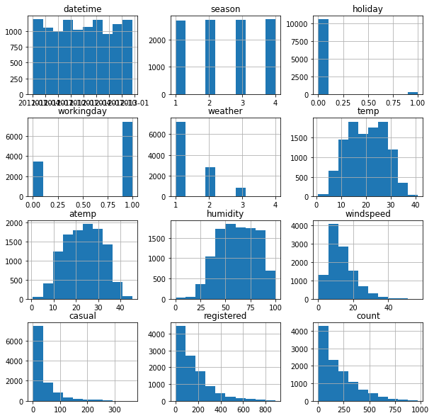

```python
# Create a histogram of all features to show the distribution of each one relative to the data. This is part of the exploritory data analysis
train.hist(figsize=(10, 10));
```

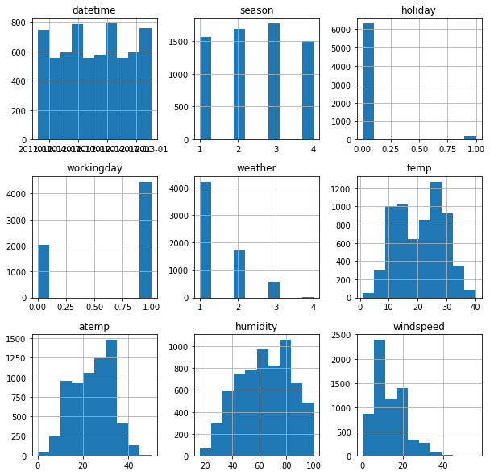

```python
# create a histogram of the features in the test data to check (visually) if the features are similarly distributed.
test.hist(figsize=(10, 10));
```

The feaure distributions in the `train` and `test` data sets are similar, based on a quick, visual comparison.

```python
# create new 'hour', 'day' and 'month' features
train['hour'] = train['datetime'].dt.hour
test['hour'] = test['datetime'].dt.hour

train['day'] = train['datetime'].dt.day
test['day'] = test['datetime'].dt.day

train['month'] = train['datetime'].dt.month
test['month'] = test['datetime'].dt.month
```

## Make category types for these so models know they are not just numbers

- AutoGluon originally sees these as ints, but in reality they are int representations of a category.
- Setting the dtype to category will classify these as categories in AutoGluon.

The `hour`, `day` and `month` features should be categorical.

```python
train["season"] = train['season'].astype('category')
train["weather"] = train["weather"].astype('category')
train["hour"] = train["hour"].astype('category')
train["day"] = train["day"].astype('category')
train["month"] = train["month"].astype('category')

test["season"] = test["season"].astype('category')
test["weather"] = test["weather"].astype('category')
test["hour"] = test["hour"].astype('category')
test["day"] = test["day"].astype('category')
test["month"] = test["month"].astype('category')
```

```python
# View are new feature
train.head()
```

|  | datetime | season | holiday | workingday | weather | temp | atemp | humidity | windspeed | casual | registered | count | hour | day | month |
| --- | --- | --- | --- | --- | --- | --- | --- | --- | --- | --- | --- | --- | --- | --- | --- |
| 0 | 2011-01-01 00:00:00 | 1 | 0 | 0 | 1 | 9.84 | 14.395 | 81 | 0.0 | 3 | 13 | 16 | 0 | 1 | 1 |
| 1 | 2011-01-01 01:00:00 | 1 | 0 | 0 | 1 | 9.02 | 13.635 | 80 | 0.0 | 8 | 32 | 40 | 1 | 1 | 1 |
| 2 | 2011-01-01 02:00:00 | 1 | 0 | 0 | 1 | 9.02 | 13.635 | 80 | 0.0 | 5 | 27 | 32 | 2 | 1 | 1 |
| 3 | 2011-01-01 03:00:00 | 1 | 0 | 0 | 1 | 9.84 | 14.395 | 75 | 0.0 | 3 | 10 | 13 | 3 | 1 | 1 |
| 4 | 2011-01-01 04:00:00 | 1 | 0 | 0 | 1 | 9.84 | 14.395 | 75 | 0.0 | 0 | 1 | 1 | 4 | 1 | 1 |

```python
train.info()
```

```
<class 'pandas.core.frame.DataFrame'>
RangeIndex: 10886 entries, 0 to 10885
Data columns (total 15 columns):
 #   Column      Non-Null Count  Dtype
---  ------      --------------  -----
 0   datetime    10886 non-null  datetime64[ns]
 1   season      10886 non-null  category
 2   holiday     10886 non-null  int64
 3   workingday  10886 non-null  int64
 4   weather     10886 non-null  category
 5   temp        10886 non-null  float64
 6   atemp       10886 non-null  float64
 7   humidity    10886 non-null  int64
 8   windspeed   10886 non-null  float64
 9   casual      10886 non-null  int64
 10  registered  10886 non-null  int64
 11  count       10886 non-null  int64
 12  hour        10886 non-null  category
 13  day         10886 non-null  category
 14  month       10886 non-null  category
dtypes: category(5), datetime64[ns](1), float64(3), int64(6)
memory usage: 906.0 KB
```

## Step 5: Rerun the model with the same settings as before, just with more features

```python
predictor_new_features = TabularPredictor(label=count,
                                          learner_kwargs=learner_kwargs,
                                          eval_metric='root_mean_squared_error').fit(train,
                                                                                     presets='best_quality',
                                                                                     excluded_model_types=['KNN', 'NN', 'FASTAI'],
                                                                                     time_limit=time_limit)
```

```
No path specified. Models will be saved in: "AutogluonModels/ag-20211115_014735/"
Presets specified: ['best_quality']
Beginning AutoGluon training ... Time limit = 600s
AutoGluon will save models to "AutogluonModels/ag-20211115_014735/"
AutoGluon Version:  0.3.1
Train Data Rows:    10886
Train Data Columns: 14
Preprocessing data ...
AutoGluon infers your prediction problem is: 'regression' (because dtype of label-column == int and many unique label-values observed).
	Label info (max, min, mean, stddev): (977, 1, 191.57413, 181.14445)
	If 'regression' is not the correct problem_type, please manually specify the problem_type argument in fit() (You may specify problem_type as one of: ['binary', 'multiclass', 'regression'])
Using Feature Generators to preprocess the data ...
Dropping user-specified ignored columns: ['registered', 'casual']
Fitting AutoMLPipelineFeatureGenerator...
	Available Memory:                    2153.69 MB
	Train Data (Original)  Memory Usage: 0.66 MB (0.0% of available memory)
	Inferring data type of each feature based on column values. Set feature_metadata_in to manually specify special dtypes of the features.
	Stage 1 Generators:
		Fitting AsTypeFeatureGenerator...
			Note: Converting 2 features to boolean dtype as they only contain 2 unique values.
	Stage 2 Generators:
		Fitting FillNaFeatureGenerator...
	Stage 3 Generators:
		Fitting IdentityFeatureGenerator...
		Fitting CategoryFeatureGenerator...
			Fitting CategoryMemoryMinimizeFeatureGenerator...
		Fitting DatetimeFeatureGenerator...
	Stage 4 Generators:
		Fitting DropUniqueFeatureGenerator...
	Types of features in original data (raw dtype, special dtypes):
		('category', []) : 5 | ['season', 'weather', 'hour', 'day', 'month']
		('datetime', []) : 1 | ['datetime']
		('float', [])    : 3 | ['temp', 'atemp', 'windspeed']
		('int', [])      : 3 | ['holiday', 'workingday', 'humidity']
	Types of features in processed data (raw dtype, special dtypes):
		('category', [])             : 5 | ['season', 'weather', 'hour', 'day', 'month']
		('float', [])                : 3 | ['temp', 'atemp', 'windspeed']
		('int', [])                  : 1 | ['humidity']
		('int', ['bool'])            : 2 | ['holiday', 'workingday']
		('int', ['datetime_as_int']) : 1 | ['datetime']
	0.4s = Fit runtime
	12 features in original data used to generate 12 features in processed data.
	Train Data (Processed) Memory Usage: 0.51 MB (0.0% of available memory)
Data preprocessing and feature engineering runtime = 0.46s ...
AutoGluon will gauge predictive performance using evaluation metric: 'root_mean_squared_error'
	To change this, specify the eval_metric argument of fit()
AutoGluon will fit 2 stack levels (L1 to L2) ...
Excluded Model Types: ['KNN', 'NN', 'FASTAI']
	Found 'NN' model in hyperparameters, but 'NN' is present in `excluded_model_types` and will be removed.
	Found 'FASTAI' model in hyperparameters, but 'FASTAI' is present in `excluded_model_types` and will be removed.
	Found 'KNN' model in hyperparameters, but 'KNN' is present in `excluded_model_types` and will be removed.
	Found 'KNN' model in hyperparameters, but 'KNN' is present in `excluded_model_types` and will be removed.
Fitting 7 L1 models ...
Fitting model: LightGBMXT_BAG_L1 ... Training model for up to 399.59s of the 599.53s of remaining time.
```

[output not shown]

```
	-37.8026	 = Validation score   (root_mean_squared_error)
	50.44s	 = Training   runtime
	2.45s	 = Validation runtime
Fitting model: LightGBM_BAG_L1 ... Training model for up to 341.36s of the 541.3s of remaining time.
```

[output not shown]

```
	-38.0893	 = Validation score   (root_mean_squared_error)
	28.76s	 = Training   runtime
	1.2s	 = Validation runtime
Fitting model: RandomForestMSE_BAG_L1 ... Training model for up to 308.04s of the 507.98s of remaining time.
	-41.3016	 = Validation score   (root_mean_squared_error)
	9.67s	 = Training   runtime
	0.41s	 = Validation runtime
Fitting model: CatBoost_BAG_L1 ... Training model for up to 295.71s of the 495.64s of remaining time.
	Time limit exceeded... Skipping CatBoost_BAG_L1.
Fitting model: ExtraTreesMSE_BAG_L1 ... Training model for up to 246.86s of the 446.79s of remaining time.
	-40.9322	 = Validation score   (root_mean_squared_error)
	3.84s	 = Training   runtime
	0.4s	 = Validation runtime
Fitting model: XGBoost_BAG_L1 ... Training model for up to 240.48s of the 440.42s of remaining time.
	-42.91	 = Validation score   (root_mean_squared_error)
	38.44s	 = Training   runtime
	0.34s	 = Validation runtime
Fitting model: LightGBMLarge_BAG_L1 ... Training model for up to 198.0s of the 397.93s of remaining time.
```

[output not shown]

```
	Ran out of time, early stopping on iteration 6318. Best iteration is:
	[6124]	train_set's rmse: 0.0239239	valid_set's rmse: 37.5786
```

```
[1000]	train_set's rmse: 6.24021	valid_set's rmse: 42.2759
[1000]	train_set's rmse: 6.23971	valid_set's rmse: 36.1429
[2000]	train_set's rmse: 1.87933	valid_set's rmse: 36.0389
[1000]	train_set's rmse: 6.45449	valid_set's rmse: 38.0709
[2000]	train_set's rmse: 1.91421	valid_set's rmse: 37.8934
[1000]	train_set's rmse: 6.32197	valid_set's rmse: 35.7353
[2000]	train_set's rmse: 1.9224	valid_set's rmse: 35.6106
```

```
	-38.5662	 = Validation score   (root_mean_squared_error)
	100.04s	 = Training   runtime
	2.53s	 = Validation runtime
Completed 1/20 k-fold bagging repeats ...
Fitting model: WeightedEnsemble_L2 ... Training model for up to 360.0s of the 281.84s of remaining time.
	-36.4178	 = Validation score   (root_mean_squared_error)
	0.31s	 = Training   runtime
	0.0s	 = Validation runtime
Excluded Model Types: ['KNN', 'NN', 'FASTAI']
	Found 'NN' model in hyperparameters, but 'NN' is present in `excluded_model_types` and will be removed.
	Found 'FASTAI' model in hyperparameters, but 'FASTAI' is present in `excluded_model_types` and will be removed.
	Found 'KNN' model in hyperparameters, but 'KNN' is present in `excluded_model_types` and will be removed.
	Found 'KNN' model in hyperparameters, but 'KNN' is present in `excluded_model_types` and will be removed.
Fitting 7 L2 models ...
Fitting model: LightGBMXT_BAG_L2 ... Training model for up to 281.44s of the 281.41s of remaining time.
	-37.5859	 = Validation score   (root_mean_squared_error)
	7.54s	 = Training   runtime
	0.17s	 = Validation runtime
Fitting model: LightGBM_BAG_L2 ... Training model for up to 273.08s of the 273.05s of remaining time.
	-37.2545	 = Validation score   (root_mean_squared_error)
	6.73s	 = Training   runtime
	0.11s	 = Validation runtime
Fitting model: RandomForestMSE_BAG_L2 ... Training model for up to 265.7s of the 265.67s of remaining time.
	-37.2549	 = Validation score   (root_mean_squared_error)
	22.28s	 = Training   runtime
	0.46s	 = Validation runtime
Fitting model: CatBoost_BAG_L2 ... Training model for up to 240.8s of the 240.77s of remaining time.
	-37.0472	 = Validation score   (root_mean_squared_error)
	35.44s	 = Training   runtime
	0.1s	 = Validation runtime
Fitting model: ExtraTreesMSE_BAG_L2 ... Training model for up to 204.77s of the 204.74s of remaining time.
	-36.8205	 = Validation score   (root_mean_squared_error)
	5.95s	 = Training   runtime
	0.45s	 = Validation runtime
Fitting model: XGBoost_BAG_L2 ... Training model for up to 196.1s of the 196.07s of remaining time.
	-37.7078	 = Validation score   (root_mean_squared_error)
	10.48s	 = Training   runtime
	0.12s	 = Validation runtime
Fitting model: LightGBMLarge_BAG_L2 ... Training model for up to 184.45s of the 184.42s of remaining time.
	-38.0438	 = Validation score   (root_mean_squared_error)
```

[output cut: 15 more lines]

```
Fitting model: XGBoost_BAG_L2 ... Training model for up to 95.81s of the 95.78s of remaining time.
	-37.4362	 = Validation score   (root_mean_squared_error)
	21.12s	 = Training   runtime
	0.24s	 = Validation runtime
Fitting model: LightGBMLarge_BAG_L2 ... Training model for up to 84.04s of the 84.02s of remaining time.
	-37.6417	 = Validation score   (root_mean_squared_error)
	35.69s	 = Training   runtime
	0.33s	 = Validation runtime
Completed 2/20 k-fold bagging repeats ...
Fitting model: WeightedEnsemble_L3 ... Training model for up to 360.0s of the 64.58s of remaining time.
	-36.565	 = Validation score   (root_mean_squared_error)
	0.35s	 = Training   runtime
	0.0s	 = Validation runtime
AutoGluon training complete, total runtime = 536.0s ...
TabularPredictor saved. To load, use: predictor = TabularPredictor.load("AutogluonModels/ag-20211115_014735/")
```

### Visually check how well the model fit the training data

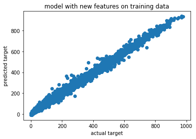

```python
visual_check(train, count, predictor_new_features, 'model with new features on training data')
```

**Remark**: the above scatter plot is more tightly grouped than the one for the base model following inclusion of `hour`, `day` and `month` as categorical features and conversion of `season` and `weather` to categorical features - at least as far as fitting the `train` data set. The model is now able to predict more of the higher instances of `count`. We will find out whether this resulted in overfitting when we obtain the Kaggle score!

```python
predictor_new_features.fit_summary()
```

```
*** Summary of fit() ***
Estimated performance of each model:
                     model  score_val  pred_time_val    fit_time  pred_time_val_marginal  fit_time_marginal  stack_level  can_infer  fit_order
0      WeightedEnsemble_L2 -36.417786       6.980270  193.061604                0.000633           0.312403            2       True          7
1      WeightedEnsemble_L3 -36.564968       8.753524  363.207004                0.000685           0.348526            3       True         15
2     ExtraTreesMSE_BAG_L2 -36.820478       7.773554  237.135684                0.453708           5.945602            2       True         12
3          CatBoost_BAG_L2 -36.860964       7.515991  319.856846                0.196146          88.666763            2       True         11
4          LightGBM_BAG_L2 -37.144665       7.539372  244.579910                0.219526          13.389828            2       True          9
5   RandomForestMSE_BAG_L2 -37.254941       7.783405  253.467634                0.463560          22.277551            2       True         10
6        LightGBMXT_BAG_L2 -37.353960       7.639426  245.968562                0.319580          14.778479            2       True          8
7           XGBoost_BAG_L2 -37.436244       7.561298  252.308773                0.241453          21.118691            2       True         13
8     LightGBMLarge_BAG_L2 -37.641738       7.649865  266.879417                0.330019          35.689335            2       True         14
9        LightGBMXT_BAG_L1 -37.802629       2.445900   50.441971                2.445900          50.441971            1       True          1
10         LightGBM_BAG_L1 -38.089302       1.197702   28.761469                1.197702          28.761469            1       True          2
11    LightGBMLarge_BAG_L1 -38.566222       2.529303  100.038673                2.529303         100.038673            1       True          6
12    ExtraTreesMSE_BAG_L1 -40.932235       0.397872    3.841919                0.397872           3.841919            1       True          4
13  RandomForestMSE_BAG_L1 -41.301613       0.408860    9.665170                0.408860           9.665170            1       True          3
14          XGBoost_BAG_L1 -42.910003       0.340209   38.440881                0.340209          38.440881            1       True          5
Number of models trained: 15
Types of models trained:
{'StackerEnsembleModel_LGB', 'StackerEnsembleModel_XT', 'StackerEnsembleModel_CatBoost', 'StackerEnsembleModel_RF', 'StackerEnsembleModel_XGBoost', 'WeightedEnsembleModel'}
Bagging used: True  (with 10 folds)
Multi-layer stack-ensembling used: True  (with 3 levels)
Feature Metadata (Processed):
(raw dtype, special dtypes):
('category', [])             : 5 | ['season', 'weather', 'hour', 'day', 'month']
('float', [])                : 3 | ['temp', 'atemp', 'windspeed']
('int', [])                  : 1 | ['humidity']
('int', ['bool'])            : 2 | ['holiday', 'workingday']
('int', ['datetime_as_int']) : 1 | ['datetime']
Plot summary of models saved to file: AutogluonModels/ag-20211115_014735/SummaryOfModels.html
*** End of fit() summary ***
```

```
{'model_types': {'LightGBMXT_BAG_L1': 'StackerEnsembleModel_LGB',
  'LightGBM_BAG_L1': 'StackerEnsembleModel_LGB',
  'RandomForestMSE_BAG_L1': 'StackerEnsembleModel_RF',
  'ExtraTreesMSE_BAG_L1': 'StackerEnsembleModel_XT',
  'XGBoost_BAG_L1': 'StackerEnsembleModel_XGBoost',
  'LightGBMLarge_BAG_L1': 'StackerEnsembleModel_LGB',
  'WeightedEnsemble_L2': 'WeightedEnsembleModel',
  'LightGBMXT_BAG_L2': 'StackerEnsembleModel_LGB',
  'LightGBM_BAG_L2': 'StackerEnsembleModel_LGB',
  'RandomForestMSE_BAG_L2': 'StackerEnsembleModel_RF',
  'CatBoost_BAG_L2': 'StackerEnsembleModel_CatBoost',
  'ExtraTreesMSE_BAG_L2': 'StackerEnsembleModel_XT',
  'XGBoost_BAG_L2': 'StackerEnsembleModel_XGBoost',
  'LightGBMLarge_BAG_L2': 'StackerEnsembleModel_LGB',
  'WeightedEnsemble_L3': 'WeightedEnsembleModel'},
 'model_performance': {'LightGBMXT_BAG_L1': -37.80262925305335,
  'LightGBM_BAG_L1': -38.08930169609092,
  'RandomForestMSE_BAG_L1': -41.301612881085475,
  'ExtraTreesMSE_BAG_L1': -40.932234641967526,
  'XGBoost_BAG_L1': -42.910002793037826,
  'LightGBMLarge_BAG_L1': -38.566222436930396,
  'WeightedEnsemble_L2': -36.41778639692457,
  'LightGBMXT_BAG_L2': -37.35395977853789,
  'LightGBM_BAG_L2': -37.144665025560776,
  'RandomForestMSE_BAG_L2': -37.254940854083905,
  'CatBoost_BAG_L2': -36.86096434184115,
  'ExtraTreesMSE_BAG_L2': -36.8204776982361,
  'XGBoost_BAG_L2': -37.436243877734285,
  'LightGBMLarge_BAG_L2': -37.64173788233261,
  'WeightedEnsemble_L3': -36.56496802718356},
 'model_best': 'WeightedEnsemble_L2',
 'model_paths': {'LightGBMXT_BAG_L1': 'AutogluonModels/ag-20211115_014735/models/LightGBMXT_BAG_L1/',
  'LightGBM_BAG_L1': 'AutogluonModels/ag-20211115_014735/models/LightGBM_BAG_L1/',
  'RandomForestMSE_BAG_L1': 'AutogluonModels/ag-20211115_014735/models/RandomForestMSE_BAG_L1/',
  'ExtraTreesMSE_BAG_L1': 'AutogluonModels/ag-20211115_014735/models/ExtraTreesMSE_BAG_L1/',
  'XGBoost_BAG_L1': 'AutogluonModels/ag-20211115_014735/models/XGBoost_BAG_L1/',
  'LightGBMLarge_BAG_L1': 'AutogluonModels/ag-20211115_014735/models/LightGBMLarge_BAG_L1/',
  'WeightedEnsemble_L2': 'AutogluonModels/ag-20211115_014735/models/WeightedEnsemble_L2/',
  'LightGBMXT_BAG_L2': 'AutogluonModels/ag-20211115_014735/models/LightGBMXT_BAG_L2/',
  'LightGBM_BAG_L2': 'AutogluonModels/ag-20211115_014735/models/LightGBM_BAG_L2/',
```

[output cut: 137 more lines]

```
 0           7
 1          15
 2          12
 3          11
 4           9
 5          10
 6           8
 7          13
 8          14
 9           1
 10          2
 11          6
 12          4
 13          3
 14          5  }
```

```python
predictions = predictor_new_features.predict(test)
```

```python
# Remember to set all negative values to zero
predictions[predictions < 0] = 0
```

```python
# Same submitting predictions
submission_new_features = pd.read_csv('sampleSubmission.csv', parse_dates=['datetime'])
submission_new_features["count"] = predictions
submission_new_features.to_csv("submission_new_features.csv", index=False)
```

```python
!kaggle competitions submit -c bike-sharing-demand -f submission_new_features.csv -m "new features"
```

```
Successfully submitted to Bike Sharing Demand
```

```python
!kaggle competitions submissions -c bike-sharing-demand | tail -n +1 | head -n 6
```

```
fileName                      date                 description                        status    publicScore  privateScore
----------------------------  -------------------  ---------------------------------  --------  -----------  ------------
submission_new_features.csv   2021-11-15 01:58:18  new features                       complete  0.50192      0.50192
submission.csv                2021-11-15 01:43:28  first raw submission               complete  1.39412      1.39412
submission_mean_abs_err.csv   2021-11-13 23:54:07  mean absolute error                complete  0.44690      0.44690
submission_more_features.csv  2021-11-13 23:35:13  new features 2                     complete  0.53994      0.53994
```

#### New Score of `0.50192`

## Step 6: Hyper parameter optimization

- There are many options for hyper parameter optimization.
- Options are to change the AutoGluon higher level parameters or the individual model hyperparameters.
- The hyperparameters of the models themselves that are in AutoGluon. Those need the `hyperparameter` and `hyperparameter_tune_kwargs` arguments.

The options for `excluded_model_types` and `hyperparameter_tune_kwargs` were based on documentation and tutorials found here: https://auto.gluon.ai/dev/api/autogluon.task.html#autogluon.tabular.TabularPredictor.fit https://auto.gluon.ai/stable/tutorials/tabular_prediction/tabular-indepth.html#specifying-hyperparameters-and-tuning-them

```python
hyperparameter_tune_kwargs = {
    'num_trials': 20,
    'scheduler': 'local',
    'searcher': 'random'
}
```

```python
predictor_new_hpo = TabularPredictor(label=count,
                                     learner_kwargs=learner_kwargs,
                                     eval_metric='root_mean_squared_error').fit(train,
                                                                                presets='best_quality',
                                                                                time_limit=time_limit * 1.5,
                                                                                excluded_model_types=['KNN', 'NN', 'FASTAI'],
                                                                                hyperparameter_tune_kwargs=hyperparameter_tune_kwargs)
```

```
No path specified. Models will be saved in: "AutogluonModels/ag-20211115_015914/"
Presets specified: ['best_quality']
Warning: hyperparameter tuning is currently experimental and may cause the process to hang.
Beginning AutoGluon training ... Time limit = 900.0s
AutoGluon will save models to "AutogluonModels/ag-20211115_015914/"
AutoGluon Version:  0.3.1
Train Data Rows:    10886
Train Data Columns: 14
Preprocessing data ...
AutoGluon infers your prediction problem is: 'regression' (because dtype of label-column == int and many unique label-values observed).
	Label info (max, min, mean, stddev): (977, 1, 191.57413, 181.14445)
	If 'regression' is not the correct problem_type, please manually specify the problem_type argument in fit() (You may specify problem_type as one of: ['binary', 'multiclass', 'regression'])
Using Feature Generators to preprocess the data ...
Dropping user-specified ignored columns: ['registered', 'casual']
Fitting AutoMLPipelineFeatureGenerator...
	Available Memory:                    1961.82 MB
	Train Data (Original)  Memory Usage: 0.66 MB (0.0% of available memory)
	Inferring data type of each feature based on column values. Set feature_metadata_in to manually specify special dtypes of the features.
	Stage 1 Generators:
		Fitting AsTypeFeatureGenerator...
			Note: Converting 2 features to boolean dtype as they only contain 2 unique values.
	Stage 2 Generators:
		Fitting FillNaFeatureGenerator...
	Stage 3 Generators:
		Fitting IdentityFeatureGenerator...
		Fitting CategoryFeatureGenerator...
			Fitting CategoryMemoryMinimizeFeatureGenerator...
		Fitting DatetimeFeatureGenerator...
	Stage 4 Generators:
		Fitting DropUniqueFeatureGenerator...
	Types of features in original data (raw dtype, special dtypes):
		('category', []) : 5 | ['season', 'weather', 'hour', 'day', 'month']
		('datetime', []) : 1 | ['datetime']
		('float', [])    : 3 | ['temp', 'atemp', 'windspeed']
		('int', [])      : 3 | ['holiday', 'workingday', 'humidity']
	Types of features in processed data (raw dtype, special dtypes):
		('category', [])             : 5 | ['season', 'weather', 'hour', 'day', 'month']
		('float', [])                : 3 | ['temp', 'atemp', 'windspeed']
		('int', [])                  : 1 | ['humidity']
		('int', ['bool'])            : 2 | ['holiday', 'workingday']
```

[output cut: 130 more lines]

[output not shown]

```
[1000]	train_set's rmse: 6.37607	valid_set's rmse: 36.1907
```

```
	Ran out of time, early stopping on iteration 1685. Best iteration is:
	[1676]	train_set's rmse: 2.76547	valid_set's rmse: 36.1197
	-36.1197	 = Validation score   (root_mean_squared_error)
	7.24s	 = Training   runtime
	0.19s	 = Validation runtime
Fitting model: RandomForestMSE_BAG_L1/T0 ... Training model for up to 564.66s of the 864.73s of remaining time.
	-41.3016	 = Validation score   (root_mean_squared_error)
	9.55s	 = Training   runtime
	0.42s	 = Validation runtime
Fitting model: ExtraTreesMSE_BAG_L1/T0 ... Training model for up to 564.6s of the 864.66s of remaining time.
	-40.9322	 = Validation score   (root_mean_squared_error)
	3.94s	 = Training   runtime
	0.4s	 = Validation runtime
Fitting model: LightGBMLarge_BAG_L1 ... Training model for up to 564.53s of the 864.6s of remaining time.
```

[output not shown]

```
	-38.5662	 = Validation score   (root_mean_squared_error)
	104.82s	 = Training   runtime
	2.44s	 = Validation runtime
Repeating k-fold bagging: 2/20
Fitting model: LightGBMLarge_BAG_L1 ... Training model for up to 452.26s of the 752.33s of remaining time.
```

[output not shown]

```
	-38.0865	 = Validation score   (root_mean_squared_error)
	202.67s	 = Training   runtime
	4.74s	 = Validation runtime
Repeating k-fold bagging: 3/20
Fitting model: LightGBMLarge_BAG_L1 ... Training model for up to 339.75s of the 639.82s of remaining time.
```

[output not shown]

```
	-37.9903	 = Validation score   (root_mean_squared_error)
	266.85s	 = Training   runtime
	6.23s	 = Validation runtime
Repeating k-fold bagging: 4/20
Fitting model: LightGBMLarge_BAG_L1 ... Training model for up to 265.81s of the 565.88s of remaining time.
```

[output not shown]

```
	-37.9288	 = Validation score   (root_mean_squared_error)
	352.23s	 = Training   runtime
	8.21s	 = Validation runtime
Repeating k-fold bagging: 5/20
Fitting model: LightGBMLarge_BAG_L1 ... Training model for up to 167.12s of the 467.19s of remaining time.
```

[output not shown]

```
	Ran out of time, early stopping on iteration 6901. Best iteration is:
	[6900]	train_set's rmse: 0.0106809	valid_set's rmse: 37.2642
```

```
[1000]	train_set's rmse: 6.44943	valid_set's rmse: 39.5932
[2000]	train_set's rmse: 2.01713	valid_set's rmse: 39.4673
[3000]	train_set's rmse: 0.651189	valid_set's rmse: 39.4462
[1000]	train_set's rmse: 6.387	valid_set's rmse: 34.9758
[2000]	train_set's rmse: 1.92003	valid_set's rmse: 34.7859
[3000]	train_set's rmse: 0.635045	valid_set's rmse: 34.7667
[4000]	train_set's rmse: 0.220507	valid_set's rmse: 34.7667
```

[output not shown]

[output cut: 182 more lines]

```
	-38.54	 = Validation score   (root_mean_squared_error)
	228.19s	 = Training   runtime
	2.35s	 = Validation runtime
Repeating k-fold bagging: 15/20
Fitting model: LightGBMLarge_BAG_L2 ... Training model for up to 33.24s of the 33.22s of remaining time.
	-38.5286	 = Validation score   (root_mean_squared_error)
	244.16s	 = Training   runtime
	2.51s	 = Validation runtime
Completed 15/20 k-fold bagging repeats ...
Fitting model: WeightedEnsemble_L3 ... Training model for up to 360.0s of the 15.63s of remaining time.
	-37.775	 = Validation score   (root_mean_squared_error)
	0.19s	 = Training   runtime
	0.0s	 = Validation runtime
AutoGluon training complete, total runtime = 884.79s ...
TabularPredictor saved. To load, use: predictor = TabularPredictor.load("AutogluonModels/ag-20211115_015914/")
```

### Visually check how well the model fit the training data

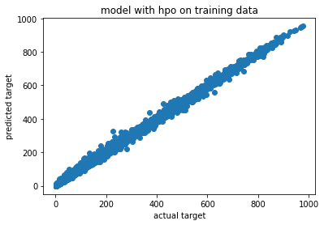

```python
visual_check(train, count, predictor_new_hpo, 'model with hpo on training data');
```

**Observation**: hyperparameter optimization of the kind performed above did not improve the evaluation metric. This is, perhaps, consistent with the advice,

*However we recommend spending most of your time on feature-engineering and just specifying presets = 'best_quality' inside the call to fit()*,

found here: https://auto.gluon.ai/dev/tutorials/tabular_prediction/tabular-kaggle.html?highlight=hyperparameter_tune_kwargs

```python
predictor_new_hpo.fit_summary()
```

```
*** Summary of fit() ***
Estimated performance of each model:
                       model  score_val  pred_time_val    fit_time  pred_time_val_marginal  fit_time_marginal  stack_level  can_infer  fit_order
0        WeightedEnsemble_L2 -37.320129      12.142154  493.238222                0.000712           0.187573            2       True          4
1        WeightedEnsemble_L3 -37.774955      15.582248  759.708451                0.000641           0.194935            3       True          8
2    ExtraTreesMSE_BAG_L2/T0 -37.787603      12.594159  498.190403                0.452717           5.139753            2       True          6
3       LightGBMLarge_BAG_L1 -37.796440      11.321638  479.557307               11.321638         479.557307            1       True          3
4       LightGBMLarge_BAG_L2 -38.528630      14.651851  737.214140                2.510409         244.163491            2       True          7
5  RandomForestMSE_BAG_L2/T0 -38.578323      12.618482  510.210272                0.477039          17.159623            2       True          5
6    ExtraTreesMSE_BAG_L1/T0 -40.932235       0.401935    3.941258                0.401935           3.941258            1       True          2
7  RandomForestMSE_BAG_L1/T0 -41.301613       0.417869    9.552085                0.417869           9.552085            1       True          1
Number of models trained: 8
Types of models trained:
{'StackerEnsembleModel_XT', 'StackerEnsembleModel_RF', 'WeightedEnsembleModel', 'StackerEnsembleModel_LGB'}
Bagging used: True  (with 10 folds)
Multi-layer stack-ensembling used: True  (with 3 levels)
Feature Metadata (Processed):
(raw dtype, special dtypes):
('category', [])             : 5 | ['season', 'weather', 'hour', 'day', 'month']
('float', [])                : 3 | ['temp', 'atemp', 'windspeed']
('int', [])                  : 1 | ['humidity']
('int', ['bool'])            : 2 | ['holiday', 'workingday']
('int', ['datetime_as_int']) : 1 | ['datetime']
Plot summary of models saved to file: AutogluonModels/ag-20211115_015914/SummaryOfModels.html
*** End of fit() summary ***
```

```
{'model_types': {'RandomForestMSE_BAG_L1/T0': 'StackerEnsembleModel_RF',
  'ExtraTreesMSE_BAG_L1/T0': 'StackerEnsembleModel_XT',
  'LightGBMLarge_BAG_L1': 'StackerEnsembleModel_LGB',
  'WeightedEnsemble_L2': 'WeightedEnsembleModel',
  'RandomForestMSE_BAG_L2/T0': 'StackerEnsembleModel_RF',
  'ExtraTreesMSE_BAG_L2/T0': 'StackerEnsembleModel_XT',
  'LightGBMLarge_BAG_L2': 'StackerEnsembleModel_LGB',
  'WeightedEnsemble_L3': 'WeightedEnsembleModel'},
 'model_performance': {'RandomForestMSE_BAG_L1/T0': -41.301612881085475,
  'ExtraTreesMSE_BAG_L1/T0': -40.932234641967526,
  'LightGBMLarge_BAG_L1': -37.79643954860279,
  'WeightedEnsemble_L2': -37.3201294750447,
  'RandomForestMSE_BAG_L2/T0': -38.57832290046969,
  'ExtraTreesMSE_BAG_L2/T0': -37.78760343547254,
  'LightGBMLarge_BAG_L2': -38.52863011736684,
  'WeightedEnsemble_L3': -37.77495503079761},
 'model_best': 'WeightedEnsemble_L2',
 'model_paths': {'RandomForestMSE_BAG_L1/T0': 'AutogluonModels/ag-20211115_015914/models/RandomForestMSE_BAG_L1/T0/',
  'ExtraTreesMSE_BAG_L1/T0': 'AutogluonModels/ag-20211115_015914/models/ExtraTreesMSE_BAG_L1/T0/',
  'LightGBMLarge_BAG_L1': 'AutogluonModels/ag-20211115_015914/models/LightGBMLarge_BAG_L1/',
  'WeightedEnsemble_L2': 'AutogluonModels/ag-20211115_015914/models/WeightedEnsemble_L2/',
  'RandomForestMSE_BAG_L2/T0': 'AutogluonModels/ag-20211115_015914/models/RandomForestMSE_BAG_L2/T0/',
  'ExtraTreesMSE_BAG_L2/T0': 'AutogluonModels/ag-20211115_015914/models/ExtraTreesMSE_BAG_L2/T0/',
  'LightGBMLarge_BAG_L2': 'AutogluonModels/ag-20211115_015914/models/LightGBMLarge_BAG_L2/',
  'WeightedEnsemble_L3': 'AutogluonModels/ag-20211115_015914/models/WeightedEnsemble_L3/'},
 'model_fit_times': {'RandomForestMSE_BAG_L1/T0': 9.552084684371948,
  'ExtraTreesMSE_BAG_L1/T0': 3.941257953643799,
  'LightGBMLarge_BAG_L1': 479.55730652809143,
  'WeightedEnsemble_L2': 0.18757319450378418,
  'RandomForestMSE_BAG_L2/T0': 17.15962314605713,
  'ExtraTreesMSE_BAG_L2/T0': 5.139753341674805,
  'LightGBMLarge_BAG_L2': 244.1634910106659,
  'WeightedEnsemble_L3': 0.19493460655212402},
 'model_pred_times': {'RandomForestMSE_BAG_L1/T0': 0.41786932945251465,
  'ExtraTreesMSE_BAG_L1/T0': 0.4019348621368408,
  'LightGBMLarge_BAG_L1': 11.321638107299805,
  'WeightedEnsemble_L2': 0.0007121562957763672,
  'RandomForestMSE_BAG_L2/T0': 0.4770393371582031,
  'ExtraTreesMSE_BAG_L2/T0': 0.4527168273925781,
  'LightGBMLarge_BAG_L2': 2.510408878326416,
```

[output cut: 53 more lines]

```
 3               11.321638         479.557307            1       True
 4                2.510409         244.163491            2       True
 5                0.477039          17.159623            2       True
 6                0.401935           3.941258            1       True
 7                0.417869           9.552085            1       True

    fit_order
 0          4
 1          8
 2          6
 3          3
 4          7
 5          5
 6          2
 7          1  }
```

```python
predictions = predictor_new_hpo.predict(test)
```

```python
# Remember to set all negative values to zero
predictions[predictions < 0] = 0
```

```python
# Same submitting predictions
submission_new_hpo = pd.read_csv('sampleSubmission.csv', parse_dates=['datetime'])
submission_new_hpo["count"] = predictions
submission_new_hpo.to_csv("submission_new_hpo.csv", index=False)
```

```python
!kaggle competitions submit -c bike-sharing-demand -f submission_new_hpo.csv -m "new features with hyperparameters"
```

```
Successfully submitted to Bike Sharing Demand
```

```python
!kaggle competitions submissions -c bike-sharing-demand | tail -n +1 | head -n 6
```

```
fileName                      date                 description                        status    publicScore  privateScore
----------------------------  -------------------  ---------------------------------  --------  -----------  ------------
submission_new_hpo.csv        2021-11-15 02:18:58  new features with hyperparameters  complete  0.50145      0.50145
submission_new_hpo.csv        2021-11-15 02:17:25  new features with hyperparameters  complete  0.50145      0.50145
submission_new_features.csv   2021-11-15 01:58:18  new features                       complete  0.50192      0.50192
submission.csv                2021-11-15 01:43:28  first raw submission               complete  1.39412      1.39412
```

#### New Score of `0.50145`

## Step 7: Additional feature engineering

```python
train.info()
```

```
<class 'pandas.core.frame.DataFrame'>
RangeIndex: 10886 entries, 0 to 10885
Data columns (total 15 columns):
 #   Column      Non-Null Count  Dtype
---  ------      --------------  -----
 0   datetime    10886 non-null  datetime64[ns]
 1   season      10886 non-null  category
 2   holiday     10886 non-null  int64
 3   workingday  10886 non-null  int64
 4   weather     10886 non-null  category
 5   temp        10886 non-null  float64
 6   atemp       10886 non-null  float64
 7   humidity    10886 non-null  int64
 8   windspeed   10886 non-null  float64
 9   casual      10886 non-null  int64
 10  registered  10886 non-null  int64
 11  count       10886 non-null  int64
 12  hour        10886 non-null  category
 13  day         10886 non-null  category
 14  month       10886 non-null  category
dtypes: category(5), datetime64[ns](1), float64(3), int64(6)
memory usage: 906.0 KB
```

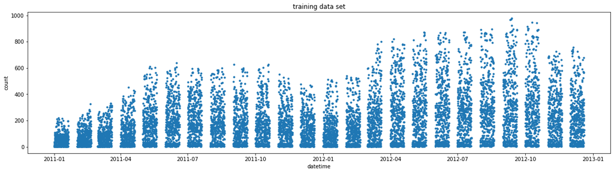

```python
# plot of `count` over time
plt.figure(figsize=(20, 5))
plt.scatter(x=train['datetime'], y=train['count'], marker='.')
plt.xlabel('datetime')
plt.ylabel('count')
plt.title('training data set')
plt.savefig('img/count-vs-datetime.png');
```

It appears that the `count` series is not stationary, but has an increasing trend with time. We will capture this by including `year` as a feature. Keep it as `int` so as to capture the trend.

```python
train['year'] = train['datetime'].dt.year
test['year'] = test['datetime'].dt.year
```

Include `dayofweek` as a categorical feature to capture weely cyclicality.

```python
train['dayofweek'] = train['datetime'].dt.dayofweek
test['dayofweek'] = test['datetime'].dt.dayofweek

train['dayofweek'] = train['dayofweek'].astype('category')
test['dayofweek'] = test['dayofweek'].astype('category')
```

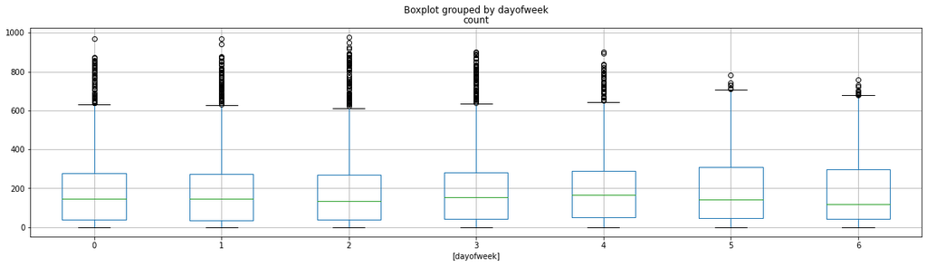

```python
train.boxplot(column=['count'], by=['dayofweek'], figsize=(20, 5))
plt.savefig('img/dayofweek-boxplot.png')
```

It would appear reasonable to include `dayofweek` as a categorical feature, from the above box plot.

```python
train.info()
```

```
<class 'pandas.core.frame.DataFrame'>
RangeIndex: 10886 entries, 0 to 10885
Data columns (total 17 columns):
 #   Column      Non-Null Count  Dtype
---  ------      --------------  -----
 0   datetime    10886 non-null  datetime64[ns]
 1   season      10886 non-null  category
 2   holiday     10886 non-null  int64
 3   workingday  10886 non-null  int64
 4   weather     10886 non-null  category
 5   temp        10886 non-null  float64
 6   atemp       10886 non-null  float64
 7   humidity    10886 non-null  int64
 8   windspeed   10886 non-null  float64
 9   casual      10886 non-null  int64
 10  registered  10886 non-null  int64
 11  count       10886 non-null  int64
 12  hour        10886 non-null  category
 13  day         10886 non-null  category
 14  month       10886 non-null  category
 15  year        10886 non-null  int64
 16  dayofweek   10886 non-null  category
dtypes: category(6), datetime64[ns](1), float64(3), int64(7)
memory usage: 1002.0 KB
```

```python
predictor_new_features_2 = TabularPredictor(label=count,
                                            learner_kwargs=learner_kwargs,
                                            eval_metric='root_mean_squared_error').fit(train,
                                                                                       presets='best_quality',
                                                                                       excluded_model_types=['NN', 'KNN', 'FASTAI'],
                                                                                       time_limit=time_limit)
```

```
No path specified. Models will be saved in: "AutogluonModels/ag-20211115_021936/"
Presets specified: ['best_quality']
Beginning AutoGluon training ... Time limit = 600s
AutoGluon will save models to "AutogluonModels/ag-20211115_021936/"
AutoGluon Version:  0.3.1
Train Data Rows:    10886
Train Data Columns: 16
Preprocessing data ...
AutoGluon infers your prediction problem is: 'regression' (because dtype of label-column == int and many unique label-values observed).
	Label info (max, min, mean, stddev): (977, 1, 191.57413, 181.14445)
	If 'regression' is not the correct problem_type, please manually specify the problem_type argument in fit() (You may specify problem_type as one of: ['binary', 'multiclass', 'regression'])
Using Feature Generators to preprocess the data ...
Dropping user-specified ignored columns: ['registered', 'casual']
Fitting AutoMLPipelineFeatureGenerator...
	Available Memory:                    1818.82 MB
	Train Data (Original)  Memory Usage: 0.76 MB (0.0% of available memory)
	Inferring data type of each feature based on column values. Set feature_metadata_in to manually specify special dtypes of the features.
	Stage 1 Generators:
		Fitting AsTypeFeatureGenerator...
			Note: Converting 3 features to boolean dtype as they only contain 2 unique values.
	Stage 2 Generators:
		Fitting FillNaFeatureGenerator...
	Stage 3 Generators:
		Fitting IdentityFeatureGenerator...
		Fitting CategoryFeatureGenerator...
			Fitting CategoryMemoryMinimizeFeatureGenerator...
		Fitting DatetimeFeatureGenerator...
	Stage 4 Generators:
		Fitting DropUniqueFeatureGenerator...
	Types of features in original data (raw dtype, special dtypes):
		('category', []) : 6 | ['season', 'weather', 'hour', 'day', 'month', ...]
		('datetime', []) : 1 | ['datetime']
		('float', [])    : 3 | ['temp', 'atemp', 'windspeed']
		('int', [])      : 4 | ['holiday', 'workingday', 'humidity', 'year']
	Types of features in processed data (raw dtype, special dtypes):
		('category', [])             : 6 | ['season', 'weather', 'hour', 'day', 'month', ...]
		('float', [])                : 3 | ['temp', 'atemp', 'windspeed']
		('int', [])                  : 1 | ['humidity']
		('int', ['bool'])            : 3 | ['holiday', 'workingday', 'year']
		('int', ['datetime_as_int']) : 1 | ['datetime']
	0.2s = Fit runtime
	14 features in original data used to generate 14 features in processed data.
	Train Data (Processed) Memory Usage: 0.54 MB (0.0% of available memory)
Data preprocessing and feature engineering runtime = 0.22s ...
AutoGluon will gauge predictive performance using evaluation metric: 'root_mean_squared_error'
	To change this, specify the eval_metric argument of fit()
AutoGluon will fit 2 stack levels (L1 to L2) ...
Excluded Model Types: ['NN', 'KNN', 'FASTAI']
	Found 'NN' model in hyperparameters, but 'NN' is present in `excluded_model_types` and will be removed.
	Found 'FASTAI' model in hyperparameters, but 'FASTAI' is present in `excluded_model_types` and will be removed.
	Found 'KNN' model in hyperparameters, but 'KNN' is present in `excluded_model_types` and will be removed.
	Found 'KNN' model in hyperparameters, but 'KNN' is present in `excluded_model_types` and will be removed.
Fitting 7 L1 models ...
Fitting model: LightGBMXT_BAG_L1 ... Training model for up to 399.76s of the 599.77s of remaining time.
```

[output not shown]

```
	-34.3357	 = Validation score   (root_mean_squared_error)
	65.04s	 = Training   runtime
	3.01s	 = Validation runtime
Fitting model: LightGBM_BAG_L1 ... Training model for up to 325.0s of the 525.02s of remaining time.
```

[output not shown]

```
	-35.0789	 = Validation score   (root_mean_squared_error)
	33.39s	 = Training   runtime
	1.33s	 = Validation runtime
Fitting model: RandomForestMSE_BAG_L1 ... Training model for up to 286.47s of the 486.48s of remaining time.
	-38.4046	 = Validation score   (root_mean_squared_error)
	10.25s	 = Training   runtime
	0.41s	 = Validation runtime
Fitting model: CatBoost_BAG_L1 ... Training model for up to 273.57s of the 473.59s of remaining time.
	Time limit exceeded... Skipping CatBoost_BAG_L1.
Fitting model: ExtraTreesMSE_BAG_L1 ... Training model for up to 224.26s of the 424.28s of remaining time.
	-38.3232	 = Validation score   (root_mean_squared_error)
	4.14s	 = Training   runtime
	0.4s	 = Validation runtime
Fitting model: XGBoost_BAG_L1 ... Training model for up to 217.65s of the 417.66s of remaining time.
	-39.8669	 = Validation score   (root_mean_squared_error)
	44.37s	 = Training   runtime
	0.37s	 = Validation runtime
Fitting model: LightGBMLarge_BAG_L1 ... Training model for up to 168.88s of the 368.89s of remaining time.
```

```
[1000]	train_set's rmse: 5.34528	valid_set's rmse: 35.0816
[2000]	train_set's rmse: 1.52252	valid_set's rmse: 35.0364
[1000]	train_set's rmse: 5.48892	valid_set's rmse: 38.1906
[2000]	train_set's rmse: 1.62194	valid_set's rmse: 37.9852
[3000]	train_set's rmse: 0.488745	valid_set's rmse: 37.9695
```

```
	Ran out of time, early stopping on iteration 4049. Best iteration is:
	[3782]	train_set's rmse: 0.203135	valid_set's rmse: 37.9635
```

[output not shown]

```
	-36.3489	 = Validation score   (root_mean_squared_error)
	78.68s	 = Training   runtime
	1.83s	 = Validation runtime
Completed 1/20 k-fold bagging repeats ...
Fitting model: WeightedEnsemble_L2 ... Training model for up to 360.0s of the 278.14s of remaining time.
	-33.2543	 = Validation score   (root_mean_squared_error)
	0.3s	 = Training   runtime
	0.0s	 = Validation runtime
Excluded Model Types: ['NN', 'KNN', 'FASTAI']
	Found 'NN' model in hyperparameters, but 'NN' is present in `excluded_model_types` and will be removed.
	Found 'FASTAI' model in hyperparameters, but 'FASTAI' is present in `excluded_model_types` and will be removed.
	Found 'KNN' model in hyperparameters, but 'KNN' is present in `excluded_model_types` and will be removed.
	Found 'KNN' model in hyperparameters, but 'KNN' is present in `excluded_model_types` and will be removed.
Fitting 7 L2 models ...
Fitting model: LightGBMXT_BAG_L2 ... Training model for up to 277.74s of the 277.71s of remaining time.
	-34.8235	 = Validation score   (root_mean_squared_error)
	8.69s	 = Training   runtime
	0.18s	 = Validation runtime
Fitting model: LightGBM_BAG_L2 ... Training model for up to 268.18s of the 268.15s of remaining time.
	-33.8594	 = Validation score   (root_mean_squared_error)
	6.86s	 = Training   runtime
	0.11s	 = Validation runtime
Fitting model: RandomForestMSE_BAG_L2 ... Training model for up to 260.67s of the 260.64s of remaining time.
	-34.1816	 = Validation score   (root_mean_squared_error)
	23.58s	 = Training   runtime
	0.47s	 = Validation runtime
Fitting model: CatBoost_BAG_L2 ... Training model for up to 234.69s of the 234.65s of remaining time.
	-33.6667	 = Validation score   (root_mean_squared_error)
	59.83s	 = Training   runtime
	0.12s	 = Validation runtime
Fitting model: ExtraTreesMSE_BAG_L2 ... Training model for up to 174.21s of the 174.18s of remaining time.
	-33.8435	 = Validation score   (root_mean_squared_error)
	6.55s	 = Training   runtime
	0.46s	 = Validation runtime
Fitting model: XGBoost_BAG_L2 ... Training model for up to 165.2s of the 165.16s of remaining time.
	-34.42	 = Validation score   (root_mean_squared_error)
	11.58s	 = Training   runtime
	0.14s	 = Validation runtime
Fitting model: LightGBMLarge_BAG_L2 ... Training model for up to 152.38s of the 152.35s of remaining time.
	-34.668	 = Validation score   (root_mean_squared_error)
	19.31s	 = Training   runtime
	0.17s	 = Validation runtime
Completed 1/20 k-fold bagging repeats ...
Fitting model: WeightedEnsemble_L3 ... Training model for up to 360.0s of the 131.36s of remaining time.
	-33.4093	 = Validation score   (root_mean_squared_error)
	0.35s	 = Training   runtime
	0.0s	 = Validation runtime
AutoGluon training complete, total runtime = 469.23s ...
TabularPredictor saved. To load, use: predictor = TabularPredictor.load("AutogluonModels/ag-20211115_021936/")
```

### Visually check how well the model fit the training data

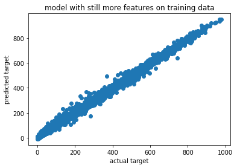

```python
visual_check(train, count, predictor_new_features_2, 'model with still more features on training data')
```

**Remark**: additional feature engineering has tightened this grouping noticeably.

```python
predictor_new_features_2.fit_summary()
```

```
*** Summary of fit() ***
Estimated performance of each model:
                     model  score_val  pred_time_val    fit_time  pred_time_val_marginal  fit_time_marginal  stack_level  can_infer  fit_order
0      WeightedEnsemble_L2 -33.254330       6.980184  191.803803                0.000683           0.304903            2       True          7
1      WeightedEnsemble_L3 -33.409294       8.640104  344.621024                0.000683           0.349001            3       True         15
2          CatBoost_BAG_L2 -33.666744       7.465369  295.700733                0.115417          59.830458            2       True         11
3     ExtraTreesMSE_BAG_L2 -33.843541       7.806980  242.421932                0.457027           6.551657            2       True         12
4          LightGBM_BAG_L2 -33.859440       7.462265  242.727128                0.112313           6.856853            2       True          9
5   RandomForestMSE_BAG_L2 -34.181645       7.817521  259.454028                0.467568          23.583754            2       True         10
6        LightGBMXT_BAG_L1 -34.335720       3.006095   65.040784                3.006095          65.040784            1       True          1
7           XGBoost_BAG_L2 -34.420038       7.487096  247.449301                0.137144          11.579026            2       True         13
8     LightGBMLarge_BAG_L2 -34.668046       7.519829  255.181769                0.169877          19.311494            2       True         14
9        LightGBMXT_BAG_L2 -34.823506       7.534225  244.564649                0.184273           8.694374            2       True          8
10         LightGBM_BAG_L1 -35.078872       1.333626   33.389211                1.333626          33.389211            1       True          2
11    LightGBMLarge_BAG_L1 -36.348942       1.826714   78.678307                1.826714          78.678307            1       True          6
12    ExtraTreesMSE_BAG_L1 -38.323158       0.404107    4.138858                0.404107           4.138858            1       True          4
13  RandomForestMSE_BAG_L1 -38.404592       0.408959   10.251739                0.408959          10.251739            1       True          3
14          XGBoost_BAG_L1 -39.866937       0.370451   44.371375                0.370451          44.371375            1       True          5
Number of models trained: 15
Types of models trained:
{'StackerEnsembleModel_LGB', 'StackerEnsembleModel_XT', 'StackerEnsembleModel_CatBoost', 'StackerEnsembleModel_RF', 'StackerEnsembleModel_XGBoost', 'WeightedEnsembleModel'}
Bagging used: True  (with 10 folds)
Multi-layer stack-ensembling used: True  (with 3 levels)
Feature Metadata (Processed):
(raw dtype, special dtypes):
('category', [])             : 6 | ['season', 'weather', 'hour', 'day', 'month', ...]
('float', [])                : 3 | ['temp', 'atemp', 'windspeed']
('int', [])                  : 1 | ['humidity']
('int', ['bool'])            : 3 | ['holiday', 'workingday', 'year']
('int', ['datetime_as_int']) : 1 | ['datetime']
Plot summary of models saved to file: AutogluonModels/ag-20211115_021936/SummaryOfModels.html
*** End of fit() summary ***
```

```
{'model_types': {'LightGBMXT_BAG_L1': 'StackerEnsembleModel_LGB',
  'LightGBM_BAG_L1': 'StackerEnsembleModel_LGB',
  'RandomForestMSE_BAG_L1': 'StackerEnsembleModel_RF',
  'ExtraTreesMSE_BAG_L1': 'StackerEnsembleModel_XT',
  'XGBoost_BAG_L1': 'StackerEnsembleModel_XGBoost',
  'LightGBMLarge_BAG_L1': 'StackerEnsembleModel_LGB',
  'WeightedEnsemble_L2': 'WeightedEnsembleModel',
  'LightGBMXT_BAG_L2': 'StackerEnsembleModel_LGB',
  'LightGBM_BAG_L2': 'StackerEnsembleModel_LGB',
  'RandomForestMSE_BAG_L2': 'StackerEnsembleModel_RF',
  'CatBoost_BAG_L2': 'StackerEnsembleModel_CatBoost',
  'ExtraTreesMSE_BAG_L2': 'StackerEnsembleModel_XT',
  'XGBoost_BAG_L2': 'StackerEnsembleModel_XGBoost',
  'LightGBMLarge_BAG_L2': 'StackerEnsembleModel_LGB',
  'WeightedEnsemble_L3': 'WeightedEnsembleModel'},
 'model_performance': {'LightGBMXT_BAG_L1': -34.33572042645933,
  'LightGBM_BAG_L1': -35.07887236939325,
  'RandomForestMSE_BAG_L1': -38.40459246864155,
  'ExtraTreesMSE_BAG_L1': -38.32315781908685,
  'XGBoost_BAG_L1': -39.86693725718923,
  'LightGBMLarge_BAG_L1': -36.34894174027581,
  'WeightedEnsemble_L2': -33.25433003483436,
  'LightGBMXT_BAG_L2': -34.82350613582545,
  'LightGBM_BAG_L2': -33.85943974172131,
  'RandomForestMSE_BAG_L2': -34.18164548008764,
  'CatBoost_BAG_L2': -33.666743857956135,
  'ExtraTreesMSE_BAG_L2': -33.8435414038844,
  'XGBoost_BAG_L2': -34.420038380131615,
  'LightGBMLarge_BAG_L2': -34.66804551164456,
  'WeightedEnsemble_L3': -33.40929398154615},
 'model_best': 'WeightedEnsemble_L2',
 'model_paths': {'LightGBMXT_BAG_L1': 'AutogluonModels/ag-20211115_021936/models/LightGBMXT_BAG_L1/',
  'LightGBM_BAG_L1': 'AutogluonModels/ag-20211115_021936/models/LightGBM_BAG_L1/',
  'RandomForestMSE_BAG_L1': 'AutogluonModels/ag-20211115_021936/models/RandomForestMSE_BAG_L1/',
  'ExtraTreesMSE_BAG_L1': 'AutogluonModels/ag-20211115_021936/models/ExtraTreesMSE_BAG_L1/',
  'XGBoost_BAG_L1': 'AutogluonModels/ag-20211115_021936/models/XGBoost_BAG_L1/',
  'LightGBMLarge_BAG_L1': 'AutogluonModels/ag-20211115_021936/models/LightGBMLarge_BAG_L1/',
  'WeightedEnsemble_L2': 'AutogluonModels/ag-20211115_021936/models/WeightedEnsemble_L2/',
  'LightGBMXT_BAG_L2': 'AutogluonModels/ag-20211115_021936/models/LightGBMXT_BAG_L2/',
  'LightGBM_BAG_L2': 'AutogluonModels/ag-20211115_021936/models/LightGBM_BAG_L2/',
```

[output cut: 137 more lines]

```
 0           7
 1          15
 2          11
 3          12
 4           9
 5          10
 6           1
 7          13
 8          14
 9           8
 10          2
 11          6
 12          4
 13          3
 14          5  }
```

```python
predictions = predictor_new_features_2.predict(test)
```

```python
# Remember to set all negative values to zero
predictions[predictions < 0] = 0
```

```python
# Same submitting predictions
submission_new_features_2 = pd.read_csv('sampleSubmission.csv', parse_dates=['datetime'])
submission_new_features_2["count"] = predictions
submission_new_features_2.to_csv("submission_new_features_2.csv", index=False)
```

```python
!kaggle competitions submit -c bike-sharing-demand -f submission_new_features_2.csv -m "new features 2"
```

```
Successfully submitted to Bike Sharing Demand
```

```python
!kaggle competitions submissions -c bike-sharing-demand | tail -n +1 | head -n 6
```

```
fileName                       date                 description                        status    publicScore  privateScore
-----------------------------  -------------------  ---------------------------------  --------  -----------  ------------
submission_new_features_2.csv  2021-11-15 02:30:06  new features 2                     complete  0.49165      0.49165
submission_new_hpo.csv         2021-11-15 02:18:58  new features with hyperparameters  complete  0.50145      0.50145
submission_new_hpo.csv         2021-11-15 02:17:25  new features with hyperparameters  complete  0.50145      0.50145
submission_new_features.csv    2021-11-15 01:58:18  new features                       complete  0.50192      0.50192
```

#### New Score of `0.49165` - adding more features helped a little!

## Step 8: Try `eval_metric='mean_absolute_error'`

```python
predictor_mean_abs_err = TabularPredictor(label=count,
                                          learner_kwargs=learner_kwargs,
                                          eval_metric='mean_absolute_error').fit(train,
                                                                                 presets='best_quality',
                                                                                 time_limit=time_limit,
                                                                                 excluded_model_types=['NN', 'KNN', 'FASTAI'])
```

```
No path specified. Models will be saved in: "AutogluonModels/ag-20211115_023154/"
Presets specified: ['best_quality']
Beginning AutoGluon training ... Time limit = 600s
AutoGluon will save models to "AutogluonModels/ag-20211115_023154/"
AutoGluon Version:  0.3.1
Train Data Rows:    10886
Train Data Columns: 16
Preprocessing data ...
AutoGluon infers your prediction problem is: 'regression' (because dtype of label-column == int and many unique label-values observed).
	Label info (max, min, mean, stddev): (977, 1, 191.57413, 181.14445)
	If 'regression' is not the correct problem_type, please manually specify the problem_type argument in fit() (You may specify problem_type as one of: ['binary', 'multiclass', 'regression'])
Using Feature Generators to preprocess the data ...
Dropping user-specified ignored columns: ['registered', 'casual']
Fitting AutoMLPipelineFeatureGenerator...
	Available Memory:                    1791.98 MB
	Train Data (Original)  Memory Usage: 0.76 MB (0.0% of available memory)
	Inferring data type of each feature based on column values. Set feature_metadata_in to manually specify special dtypes of the features.
	Stage 1 Generators:
		Fitting AsTypeFeatureGenerator...
			Note: Converting 3 features to boolean dtype as they only contain 2 unique values.
	Stage 2 Generators:
		Fitting FillNaFeatureGenerator...
	Stage 3 Generators:
		Fitting IdentityFeatureGenerator...
		Fitting CategoryFeatureGenerator...
			Fitting CategoryMemoryMinimizeFeatureGenerator...
		Fitting DatetimeFeatureGenerator...
	Stage 4 Generators:
		Fitting DropUniqueFeatureGenerator...
	Types of features in original data (raw dtype, special dtypes):
		('category', []) : 6 | ['season', 'weather', 'hour', 'day', 'month', ...]
		('datetime', []) : 1 | ['datetime']
		('float', [])    : 3 | ['temp', 'atemp', 'windspeed']
		('int', [])      : 4 | ['holiday', 'workingday', 'humidity', 'year']
	Types of features in processed data (raw dtype, special dtypes):
		('category', [])             : 6 | ['season', 'weather', 'hour', 'day', 'month', ...]
		('float', [])                : 3 | ['temp', 'atemp', 'windspeed']
		('int', [])                  : 1 | ['humidity']
		('int', ['bool'])            : 3 | ['holiday', 'workingday', 'year']
		('int', ['datetime_as_int']) : 1 | ['datetime']
	0.2s = Fit runtime
	14 features in original data used to generate 14 features in processed data.
	Train Data (Processed) Memory Usage: 0.54 MB (0.0% of available memory)
Data preprocessing and feature engineering runtime = 0.28s ...
AutoGluon will gauge predictive performance using evaluation metric: 'mean_absolute_error'
	To change this, specify the eval_metric argument of fit()
AutoGluon will fit 2 stack levels (L1 to L2) ...
Excluded Model Types: ['NN', 'KNN', 'FASTAI']
	Found 'NN' model in hyperparameters, but 'NN' is present in `excluded_model_types` and will be removed.
	Found 'FASTAI' model in hyperparameters, but 'FASTAI' is present in `excluded_model_types` and will be removed.
	Found 'KNN' model in hyperparameters, but 'KNN' is present in `excluded_model_types` and will be removed.
	Found 'KNN' model in hyperparameters, but 'KNN' is present in `excluded_model_types` and will be removed.
Fitting 7 L1 models ...
Fitting model: LightGBMXT_BAG_L1 ... Training model for up to 399.71s of the 599.71s of remaining time.
```

[output not shown]

```
	-21.5941	 = Validation score   (mean_absolute_error)
	44.61s	 = Training   runtime
	1.99s	 = Validation runtime
Fitting model: LightGBM_BAG_L1 ... Training model for up to 348.25s of the 548.24s of remaining time.
```

[output not shown]

```
	-21.8329	 = Validation score   (mean_absolute_error)
	29.77s	 = Training   runtime
	1.16s	 = Validation runtime
Fitting model: RandomForestMSE_BAG_L1 ... Training model for up to 313.91s of the 513.91s of remaining time.
	-23.116	 = Validation score   (mean_absolute_error)
	10.27s	 = Training   runtime
	0.41s	 = Validation runtime
Fitting model: CatBoost_BAG_L1 ... Training model for up to 301.17s of the 501.17s of remaining time.
	Time limit exceeded... Skipping CatBoost_BAG_L1.
Fitting model: ExtraTreesMSE_BAG_L1 ... Training model for up to 245.12s of the 445.12s of remaining time.
	-24.0501	 = Validation score   (mean_absolute_error)
	4.24s	 = Training   runtime
	0.39s	 = Validation runtime
Fitting model: XGBoost_BAG_L1 ... Training model for up to 238.3s of the 438.3s of remaining time.
	-25.3796	 = Validation score   (mean_absolute_error)
	46.88s	 = Training   runtime
	0.38s	 = Validation runtime
Fitting model: LightGBMLarge_BAG_L1 ... Training model for up to 186.87s of the 386.86s of remaining time.
```

[output not shown]

```
	-22.2274	 = Validation score   (mean_absolute_error)
	69.72s	 = Training   runtime
	1.59s	 = Validation runtime
Completed 1/20 k-fold bagging repeats ...
Fitting model: WeightedEnsemble_L2 ... Training model for up to 360.0s of the 306.61s of remaining time.
	-20.3255	 = Validation score   (mean_absolute_error)
	0.23s	 = Training   runtime
	0.0s	 = Validation runtime
Excluded Model Types: ['NN', 'KNN', 'FASTAI']
	Found 'NN' model in hyperparameters, but 'NN' is present in `excluded_model_types` and will be removed.
	Found 'FASTAI' model in hyperparameters, but 'FASTAI' is present in `excluded_model_types` and will be removed.
	Found 'KNN' model in hyperparameters, but 'KNN' is present in `excluded_model_types` and will be removed.
	Found 'KNN' model in hyperparameters, but 'KNN' is present in `excluded_model_types` and will be removed.
Fitting 7 L2 models ...
Fitting model: LightGBMXT_BAG_L2 ... Training model for up to 306.29s of the 306.26s of remaining time.
	-20.8399	 = Validation score   (mean_absolute_error)
	8.62s	 = Training   runtime
	0.2s	 = Validation runtime
Fitting model: LightGBM_BAG_L2 ... Training model for up to 296.75s of the 296.73s of remaining time.
	-20.5077	 = Validation score   (mean_absolute_error)
	7.97s	 = Training   runtime
	0.14s	 = Validation runtime
Fitting model: RandomForestMSE_BAG_L2 ... Training model for up to 288.06s of the 288.03s of remaining time.
	-20.625	 = Validation score   (mean_absolute_error)
	23.39s	 = Training   runtime
	0.46s	 = Validation runtime
Fitting model: CatBoost_BAG_L2 ... Training model for up to 262.31s of the 262.28s of remaining time.
	-20.3325	 = Validation score   (mean_absolute_error)
	102.1s	 = Training   runtime
	0.13s	 = Validation runtime
Fitting model: ExtraTreesMSE_BAG_L2 ... Training model for up to 159.46s of the 159.43s of remaining time.
	-20.3255	 = Validation score   (mean_absolute_error)
	6.45s	 = Training   runtime
	0.46s	 = Validation runtime
Fitting model: XGBoost_BAG_L2 ... Training model for up to 150.5s of the 150.47s of remaining time.
	-20.3255	 = Validation score   (mean_absolute_error)
	11.74s	 = Training   runtime
	0.14s	 = Validation runtime
Fitting model: LightGBMLarge_BAG_L2 ... Training model for up to 137.56s of the 137.54s of remaining time.
	-20.8123	 = Validation score   (mean_absolute_error)
	22.86s	 = Training   runtime
	0.21s	 = Validation runtime
Completed 1/20 k-fold bagging repeats ...
Fitting model: WeightedEnsemble_L3 ... Training model for up to 360.0s of the 112.6s of remaining time.
	-20.0606	 = Validation score   (mean_absolute_error)
	0.37s	 = Training   runtime
	0.0s	 = Validation runtime
AutoGluon training complete, total runtime = 488.02s ...
TabularPredictor saved. To load, use: predictor = TabularPredictor.load("AutogluonModels/ag-20211115_023154/")
```

### Visually check how well the model fit the training data

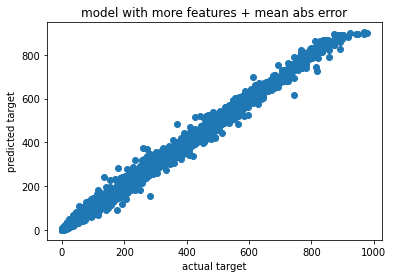

```python
visual_check(train, count, predictor_mean_abs_err, 'model with more features + mean abs error')
```

```python
predictor_mean_abs_err.fit_summary()
```

```
*** Summary of fit() ***
Estimated performance of each model:
                     model  score_val  pred_time_val    fit_time  pred_time_val_marginal  fit_time_marginal  stack_level  can_infer  fit_order
0      WeightedEnsemble_L3 -20.060574       6.857597  334.781933                0.000673           0.369321            3       True         15
1           XGBoost_BAG_L2 -20.325479       6.072584  217.236204                0.137978          11.741182            2       True         13
2     ExtraTreesMSE_BAG_L2 -20.325489       6.391713  211.947196                0.457107           6.452174            2       True         12
3      WeightedEnsemble_L2 -20.325501       5.551165  158.847585                0.000556           0.234040            2       True          7
4          CatBoost_BAG_L2 -20.332531       6.060622  307.598327                0.126016         102.103306            2       True         11
5          LightGBM_BAG_L2 -20.507745       6.070531  213.463137                0.135926           7.968115            2       True          9
6   RandomForestMSE_BAG_L2 -20.624989       6.393036  228.882304                0.458431          23.387282            2       True         10
7     LightGBMLarge_BAG_L2 -20.812333       6.148717  228.355648                0.214111          22.860626            2       True         14
8        LightGBMXT_BAG_L2 -20.839936       6.135822  214.115950                0.201216           8.620928            2       True          8
9        LightGBMXT_BAG_L1 -21.594085       1.989905   44.610359                1.989905          44.610359            1       True          1
10         LightGBM_BAG_L1 -21.832895       1.160645   29.772273                1.160645          29.772273            1       True          2
11    LightGBMLarge_BAG_L1 -22.227409       1.593602   69.722550                1.593602          69.722550            1       True          6
12  RandomForestMSE_BAG_L1 -23.116014       0.411479   10.265863                0.411479          10.265863            1       True          3
13    ExtraTreesMSE_BAG_L1 -24.050079       0.394979    4.242500                0.394979           4.242500            1       True          4
14          XGBoost_BAG_L1 -25.379558       0.383997   46.881477                0.383997          46.881477            1       True          5
Number of models trained: 15
Types of models trained:
{'StackerEnsembleModel_LGB', 'StackerEnsembleModel_XT', 'StackerEnsembleModel_CatBoost', 'StackerEnsembleModel_RF', 'StackerEnsembleModel_XGBoost', 'WeightedEnsembleModel'}
Bagging used: True  (with 10 folds)
Multi-layer stack-ensembling used: True  (with 3 levels)
Feature Metadata (Processed):
(raw dtype, special dtypes):
('category', [])             : 6 | ['season', 'weather', 'hour', 'day', 'month', ...]
('float', [])                : 3 | ['temp', 'atemp', 'windspeed']
('int', [])                  : 1 | ['humidity']
('int', ['bool'])            : 3 | ['holiday', 'workingday', 'year']
('int', ['datetime_as_int']) : 1 | ['datetime']
Plot summary of models saved to file: AutogluonModels/ag-20211115_023154/SummaryOfModels.html
*** End of fit() summary ***
```

```
{'model_types': {'LightGBMXT_BAG_L1': 'StackerEnsembleModel_LGB',
  'LightGBM_BAG_L1': 'StackerEnsembleModel_LGB',
  'RandomForestMSE_BAG_L1': 'StackerEnsembleModel_RF',
  'ExtraTreesMSE_BAG_L1': 'StackerEnsembleModel_XT',
  'XGBoost_BAG_L1': 'StackerEnsembleModel_XGBoost',
  'LightGBMLarge_BAG_L1': 'StackerEnsembleModel_LGB',
  'WeightedEnsemble_L2': 'WeightedEnsembleModel',
  'LightGBMXT_BAG_L2': 'StackerEnsembleModel_LGB',
  'LightGBM_BAG_L2': 'StackerEnsembleModel_LGB',
  'RandomForestMSE_BAG_L2': 'StackerEnsembleModel_RF',
  'CatBoost_BAG_L2': 'StackerEnsembleModel_CatBoost',
  'ExtraTreesMSE_BAG_L2': 'StackerEnsembleModel_XT',
  'XGBoost_BAG_L2': 'StackerEnsembleModel_XGBoost',
  'LightGBMLarge_BAG_L2': 'StackerEnsembleModel_LGB',
  'WeightedEnsemble_L3': 'WeightedEnsembleModel'},
 'model_performance': {'LightGBMXT_BAG_L1': -21.594084853445263,
  'LightGBM_BAG_L1': -21.832895245761517,
  'RandomForestMSE_BAG_L1': -23.11601396867858,
  'ExtraTreesMSE_BAG_L1': -24.05007923760879,
  'XGBoost_BAG_L1': -25.379558467608323,
  'LightGBMLarge_BAG_L1': -22.227409054828737,
  'WeightedEnsemble_L2': -20.3255007359891,
  'LightGBMXT_BAG_L2': -20.839935777235613,
  'LightGBM_BAG_L2': -20.507745459350005,
  'RandomForestMSE_BAG_L2': -20.62498946749899,
  'CatBoost_BAG_L2': -20.332530736446177,
  'ExtraTreesMSE_BAG_L2': -20.325489037827097,
  'XGBoost_BAG_L2': -20.32547873924393,
  'LightGBMLarge_BAG_L2': -20.81233313888306,
  'WeightedEnsemble_L3': -20.060573881242547},
 'model_best': 'WeightedEnsemble_L3',
 'model_paths': {'LightGBMXT_BAG_L1': 'AutogluonModels/ag-20211115_023154/models/LightGBMXT_BAG_L1/',
  'LightGBM_BAG_L1': 'AutogluonModels/ag-20211115_023154/models/LightGBM_BAG_L1/',
  'RandomForestMSE_BAG_L1': 'AutogluonModels/ag-20211115_023154/models/RandomForestMSE_BAG_L1/',
  'ExtraTreesMSE_BAG_L1': 'AutogluonModels/ag-20211115_023154/models/ExtraTreesMSE_BAG_L1/',
  'XGBoost_BAG_L1': 'AutogluonModels/ag-20211115_023154/models/XGBoost_BAG_L1/',
  'LightGBMLarge_BAG_L1': 'AutogluonModels/ag-20211115_023154/models/LightGBMLarge_BAG_L1/',
  'WeightedEnsemble_L2': 'AutogluonModels/ag-20211115_023154/models/WeightedEnsemble_L2/',
  'LightGBMXT_BAG_L2': 'AutogluonModels/ag-20211115_023154/models/LightGBMXT_BAG_L2/',
  'LightGBM_BAG_L2': 'AutogluonModels/ag-20211115_023154/models/LightGBM_BAG_L2/',
```

[output cut: 137 more lines]

```
 0          15
 1          13
 2          12
 3           7
 4          11
 5           9
 6          10
 7          14
 8           8
 9           1
 10          2
 11          6
 12          3
 13          4
 14          5  }
```

```python
predictions = predictor_mean_abs_err.predict(test)
```

```python
# Remember to set all negative values to zero
predictions[predictions < 0] = 0
```

```python
# Same submitting predictions
submission_mean_abs_err = pd.read_csv('sampleSubmission.csv', parse_dates=['datetime'])
submission_mean_abs_err["count"] = predictions
submission_mean_abs_err.to_csv("submission_mean_abs_err.csv", index=False)
```

```python
!kaggle competitions submit -c bike-sharing-demand -f submission_mean_abs_err.csv -m "mean absolute error"
```

```
Successfully submitted to Bike Sharing Demand
```

```python
!kaggle competitions submissions -c bike-sharing-demand | tail -n +1 | head -n 6
```

```
fileName                       date                 description                        status    publicScore  privateScore
-----------------------------  -------------------  ---------------------------------  --------  -----------  ------------
submission_mean_abs_err.csv    2021-11-15 02:41:52  mean absolute error                complete  0.44690      0.44690
submission_new_features_2.csv  2021-11-15 02:30:06  new features 2                     complete  0.49165      0.49165
submission_new_hpo.csv         2021-11-15 02:18:58  new features with hyperparameters  complete  0.50145      0.50145
submission_new_hpo.csv         2021-11-15 02:17:25  new features with hyperparameters  complete  0.50145      0.50145
```

#### New Score of `0.44690` - the new evaluation metric gave a better score.

## Step 9: Try `eval_metric='median_absolute_error'`

```python
predictor_median_abs_err = TabularPredictor(label=count,
                                            learner_kwargs=learner_kwargs,
                                            eval_metric='median_absolute_error').fit(train,
                                                                                     presets='best_quality',
                                                                                     time_limit=time_limit,
                                                                                     excluded_model_types=['NN', 'KNN', 'FASTAI'])
```

```
No path specified. Models will be saved in: "AutogluonModels/ag-20211115_025028/"
Presets specified: ['best_quality']
Beginning AutoGluon training ... Time limit = 600s
AutoGluon will save models to "AutogluonModels/ag-20211115_025028/"
AutoGluon Version:  0.3.1
Train Data Rows:    10886
Train Data Columns: 16
Preprocessing data ...
AutoGluon infers your prediction problem is: 'regression' (because dtype of label-column == int and many unique label-values observed).
	Label info (max, min, mean, stddev): (977, 1, 191.57413, 181.14445)
	If 'regression' is not the correct problem_type, please manually specify the problem_type argument in fit() (You may specify problem_type as one of: ['binary', 'multiclass', 'regression'])
Using Feature Generators to preprocess the data ...
Dropping user-specified ignored columns: ['registered', 'casual']
Fitting AutoMLPipelineFeatureGenerator...
	Available Memory:                    1636.61 MB
	Train Data (Original)  Memory Usage: 0.76 MB (0.0% of available memory)
	Inferring data type of each feature based on column values. Set feature_metadata_in to manually specify special dtypes of the features.
	Stage 1 Generators:
		Fitting AsTypeFeatureGenerator...
			Note: Converting 3 features to boolean dtype as they only contain 2 unique values.
	Stage 2 Generators:
		Fitting FillNaFeatureGenerator...
	Stage 3 Generators:
		Fitting IdentityFeatureGenerator...
		Fitting CategoryFeatureGenerator...
			Fitting CategoryMemoryMinimizeFeatureGenerator...
		Fitting DatetimeFeatureGenerator...
	Stage 4 Generators:
		Fitting DropUniqueFeatureGenerator...
	Types of features in original data (raw dtype, special dtypes):
		('category', []) : 6 | ['season', 'weather', 'hour', 'day', 'month', ...]
		('datetime', []) : 1 | ['datetime']
		('float', [])    : 3 | ['temp', 'atemp', 'windspeed']
		('int', [])      : 4 | ['holiday', 'workingday', 'humidity', 'year']
	Types of features in processed data (raw dtype, special dtypes):
		('category', [])             : 6 | ['season', 'weather', 'hour', 'day', 'month', ...]
		('float', [])                : 3 | ['temp', 'atemp', 'windspeed']
		('int', [])                  : 1 | ['humidity']
		('int', ['bool'])            : 3 | ['holiday', 'workingday', 'year']
		('int', ['datetime_as_int']) : 1 | ['datetime']
```

[output cut: 72 more lines]

```
Fitting model: XGBoost_BAG_L2 ... Training model for up to 145.62s of the 145.59s of remaining time.
	-11.7986	 = Validation score   (median_absolute_error)
	19.89s	 = Training   runtime
	0.15s	 = Validation runtime
Fitting model: LightGBMLarge_BAG_L2 ... Training model for up to 124.32s of the 124.3s of remaining time.
	-12.1846	 = Validation score   (median_absolute_error)
	27.53s	 = Training   runtime
	0.17s	 = Validation runtime
Completed 1/20 k-fold bagging repeats ...
Fitting model: WeightedEnsemble_L3 ... Training model for up to 360.0s of the 95.12s of remaining time.
	-11.5462	 = Validation score   (median_absolute_error)
	0.4s	 = Training   runtime
	0.0s	 = Validation runtime
AutoGluon training complete, total runtime = 505.55s ...
TabularPredictor saved. To load, use: predictor = TabularPredictor.load("AutogluonModels/ag-20211115_025028/")
```

### Visually check how well the model fit the training data

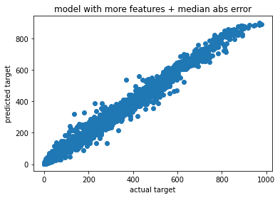

```python
visual_check(train, count, predictor_median_abs_err, 'model with more features + median abs error')
```

```python
predictor_median_abs_err.fit_summary()
```

```
*** Summary of fit() ***
Estimated performance of each model:
                     model  score_val  pred_time_val    fit_time  pred_time_val_marginal  fit_time_marginal  stack_level  can_infer  fit_order
0      WeightedEnsemble_L3 -11.546154       3.171705  456.226102                0.000787           0.397856            3       True         16
1           XGBoost_BAG_L2 -11.798592       2.165613  334.495776                0.146369          19.885022            2       True         14
2     ExtraTreesMSE_BAG_L2 -11.967567       2.478490  321.360766                0.459247           6.750013            2       True         13
3          LightGBM_BAG_L2 -12.100266       2.139460  327.407929                0.120216          12.797176            2       True         10
4   RandomForestMSE_BAG_L2 -12.173820       2.482764  339.504995                0.463520          24.894241            2       True         11
5      WeightedEnsemble_L2 -12.178535       2.020038  315.010375                0.000794           0.399621            2       True          8
6     LightGBMLarge_BAG_L2 -12.184608       2.192368  342.144218                0.173125          27.533465            2       True         15
7          CatBoost_BAG_L2 -12.189251       2.137309  375.995919                0.118065          61.385165            2       True         12
8        LightGBMXT_BAG_L2 -12.303276       2.153896  327.477405                0.134653          12.866652            2       True          9
9   RandomForestMSE_BAG_L1 -13.089554       0.406530   10.460535                0.406530          10.460535            1       True          3
10         LightGBM_BAG_L1 -13.592492       0.249906   16.517357                0.249906          16.517357            1       True          2
11    LightGBMLarge_BAG_L1 -13.621178       0.270528   25.845693                0.270528          25.845693            1       True          7
12    ExtraTreesMSE_BAG_L1 -14.429787       0.395866    4.242233                0.395866           4.242233            1       True          5
13       LightGBMXT_BAG_L1 -14.493172       0.215629   14.924753                0.215629          14.924753            1       True          1
14          XGBoost_BAG_L1 -15.856976       0.264211   37.807687                0.264211          37.807687            1       True          6
15         CatBoost_BAG_L1 -15.966033       0.216574  204.812494                0.216574         204.812494            1       True          4
Number of models trained: 16
Types of models trained:
{'StackerEnsembleModel_LGB', 'StackerEnsembleModel_CatBoost', 'StackerEnsembleModel_XT', 'StackerEnsembleModel_RF', 'StackerEnsembleModel_XGBoost', 'WeightedEnsembleModel'}
Bagging used: True  (with 10 folds)
Multi-layer stack-ensembling used: True  (with 3 levels)
Feature Metadata (Processed):
(raw dtype, special dtypes):
('category', [])             : 6 | ['season', 'weather', 'hour', 'day', 'month', ...]
('float', [])                : 3 | ['temp', 'atemp', 'windspeed']
('int', [])                  : 1 | ['humidity']
('int', ['bool'])            : 3 | ['holiday', 'workingday', 'year']
('int', ['datetime_as_int']) : 1 | ['datetime']
Plot summary of models saved to file: AutogluonModels/ag-20211115_025028/SummaryOfModels.html
*** End of fit() summary ***
```

```
{'model_types': {'LightGBMXT_BAG_L1': 'StackerEnsembleModel_LGB',
  'LightGBM_BAG_L1': 'StackerEnsembleModel_LGB',
  'RandomForestMSE_BAG_L1': 'StackerEnsembleModel_RF',
  'CatBoost_BAG_L1': 'StackerEnsembleModel_CatBoost',
  'ExtraTreesMSE_BAG_L1': 'StackerEnsembleModel_XT',
  'XGBoost_BAG_L1': 'StackerEnsembleModel_XGBoost',
  'LightGBMLarge_BAG_L1': 'StackerEnsembleModel_LGB',
  'WeightedEnsemble_L2': 'WeightedEnsembleModel',
  'LightGBMXT_BAG_L2': 'StackerEnsembleModel_LGB',
  'LightGBM_BAG_L2': 'StackerEnsembleModel_LGB',
  'RandomForestMSE_BAG_L2': 'StackerEnsembleModel_RF',
  'CatBoost_BAG_L2': 'StackerEnsembleModel_CatBoost',
  'ExtraTreesMSE_BAG_L2': 'StackerEnsembleModel_XT',
  'XGBoost_BAG_L2': 'StackerEnsembleModel_XGBoost',
  'LightGBMLarge_BAG_L2': 'StackerEnsembleModel_LGB',
  'WeightedEnsemble_L3': 'WeightedEnsembleModel'},
 'model_performance': {'LightGBMXT_BAG_L1': -14.493171691894531,
  'LightGBM_BAG_L1': -13.59249210357666,
  'RandomForestMSE_BAG_L1': -13.089553833007812,
  'CatBoost_BAG_L1': -15.966032981872559,
  'ExtraTreesMSE_BAG_L1': -14.429786682128906,
  'XGBoost_BAG_L1': -15.856975555419922,
  'LightGBMLarge_BAG_L1': -13.621177673339844,
  'WeightedEnsemble_L2': -12.178535461425781,
  'LightGBMXT_BAG_L2': -12.303276062011719,
  'LightGBM_BAG_L2': -12.100265502929688,
  'RandomForestMSE_BAG_L2': -12.173820495605469,
  'CatBoost_BAG_L2': -12.189250946044922,
  'ExtraTreesMSE_BAG_L2': -11.967567443847656,
  'XGBoost_BAG_L2': -11.798591613769531,
  'LightGBMLarge_BAG_L2': -12.18460750579834,
  'WeightedEnsemble_L3': -11.546154022216797},
 'model_best': 'WeightedEnsemble_L3',
 'model_paths': {'LightGBMXT_BAG_L1': 'AutogluonModels/ag-20211115_025028/models/LightGBMXT_BAG_L1/',
  'LightGBM_BAG_L1': 'AutogluonModels/ag-20211115_025028/models/LightGBM_BAG_L1/',
  'RandomForestMSE_BAG_L1': 'AutogluonModels/ag-20211115_025028/models/RandomForestMSE_BAG_L1/',
  'CatBoost_BAG_L1': 'AutogluonModels/ag-20211115_025028/models/CatBoost_BAG_L1/',
  'ExtraTreesMSE_BAG_L1': 'AutogluonModels/ag-20211115_025028/models/ExtraTreesMSE_BAG_L1/',
  'XGBoost_BAG_L1': 'AutogluonModels/ag-20211115_025028/models/XGBoost_BAG_L1/',
  'LightGBMLarge_BAG_L1': 'AutogluonModels/ag-20211115_025028/models/LightGBMLarge_BAG_L1/',
```

[output cut: 149 more lines]

```
 1          14
 2          13
 3          10
 4          11
 5           8
 6          15
 7          12
 8           9
 9           3
 10          2
 11          7
 12          5
 13          1
 14          6
 15          4  }
```

```python
predictions = predictor_median_abs_err.predict(test)
```

```python
# Remember to set all negative values to zero
predictions[predictions < 0] = 0
```

```python
# Same submitting predictions
submission_median_abs_err = pd.read_csv('sampleSubmission.csv', parse_dates=['datetime'])
submission_median_abs_err["count"] = predictions
submission_median_abs_err.to_csv("submission_median_abs_err.csv", index=False)
```

```python
!kaggle competitions submit -c bike-sharing-demand -f submission_median_abs_err.csv -m "median absolute error"
```

```
Successfully submitted to Bike Sharing Demand
```

```python
!kaggle competitions submissions -c bike-sharing-demand | tail -n +1 | head -n 6
```

```
fileName                       date                 description                        status    publicScore  privateScore
-----------------------------  -------------------  ---------------------------------  --------  -----------  ------------
submission_median_abs_err.csv  2021-11-15 02:59:29  median absolute error              complete  0.46272      0.46272
submission_mean_abs_err.csv    2021-11-15 02:41:52  mean absolute error                complete  0.44690      0.44690
submission_new_features_2.csv  2021-11-15 02:30:06  new features 2                     complete  0.49165      0.49165
submission_new_hpo.csv         2021-11-15 02:18:58  new features with hyperparameters  complete  0.50145      0.50145
```

#### New Score of `0.46272` - slightly inferior to using `eval_mteric='mean_absolute_error'`.